# RelativeSize

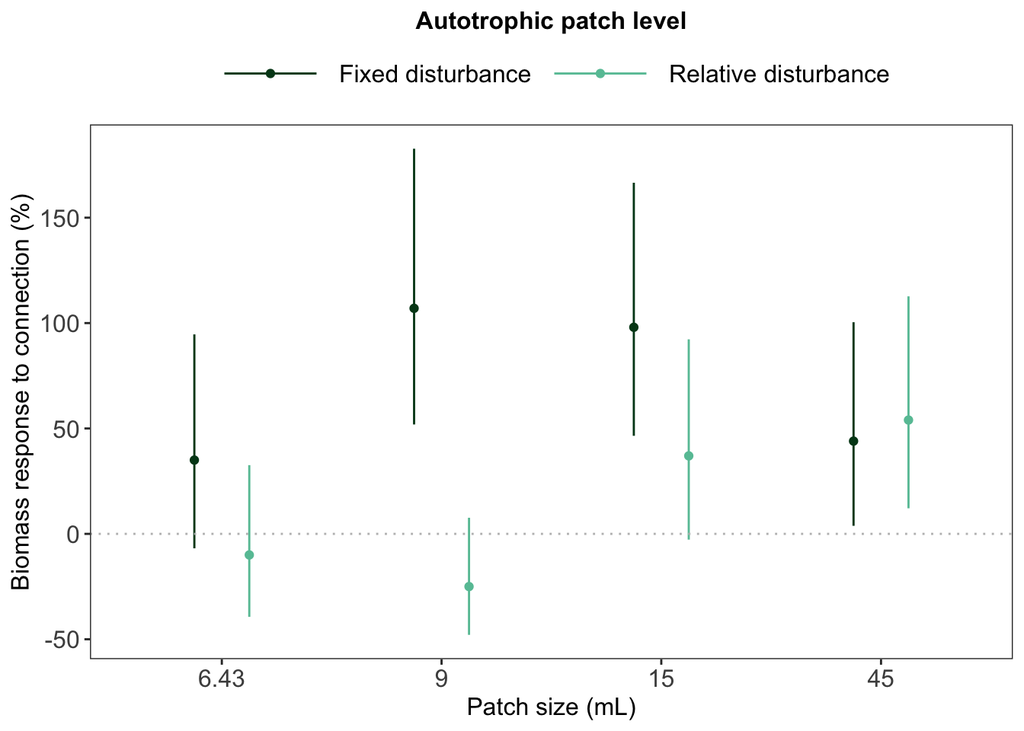

```r
plot.ecos.contrasts(contrasts,
                    trophic_type_selected,
                    response_variable_selected)
```

**Model ANOVA**

```r
# --- SHOW MODEL ANOVA --- #

car::Anova(model, type = "III")
```

```
## Analysis of Deviance Table (Type III Wald chisquare tests)
##
## Response: bioarea_mm2_per_ml
##                           Chisq Df Pr(>Chisq)
## (Intercept)              0.9693  1   0.324865
## size                   417.9843  3  < 2.2e-16 ***
## conn                     2.5031  1   0.113624
## disturb_type             7.1590  1   0.007459 **
## size:conn                5.0084  3   0.171183
## size:disturb_type      113.9947  3  < 2.2e-16 ***
## conn:disturb_type        2.1987  1   0.138130
## size:conn:disturb_type  10.3970  3   0.015476 *
## ---
## Signif. codes:  0 '***' 0.001 '**' 0.01 '*' 0.05 '.' 0.1 ' ' 1
```

**Model contrasts**

```r
# --- SHOW MODEL CONTRASTS --- #

contrasts
```

```
##            contrast percentage lower.CL upper.CL   SE z.ratio p.value
## 1     6.43 ml fixed         35    -6.86    94.63 0.25    1.58   0.114
## 2     9.00 ml fixed        107    51.90   182.71 0.33    4.60   0.000 ***
## 3    15.00 ml fixed         98    46.52   166.57 0.30    4.46   0.000 ***
## 4    45.00 ml fixed         44     3.82   100.41 0.24    2.18   0.029   *
## 5  6.43 ml relative        -10   -39.37    32.60 0.18   -0.55   0.585
## 6  9.00 ml relative        -25   -47.91     7.64 0.14   -1.56   0.118
## 7 15.00 ml relative         37    -2.73    92.29 0.24    1.80   0.072
## 8 45.00 ml relative         54    12.13   112.68 0.25    2.66   0.008  **
```

```r
nested_contrasts
```

```
##                            contrast percentage lower.CL upper.CL   SE z.ratio
## 1  Difference in effects at 6.43 ml         50   -12.26   157.00 0.41    1.48
## 2  Difference in effects at 9.00 ml        177    71.58   346.43 0.68    4.17
## 3 Difference in effects at 15.00 ml         45    -8.19   127.45 0.33    1.59
## 4 Difference in effects at 45.00 ml         -7   -40.90    47.63 0.22   -0.29
##   p.value
## 1   0.138
## 2   0.000 ***
## 3   0.112
## 4   0.770
```

**Model residuals**

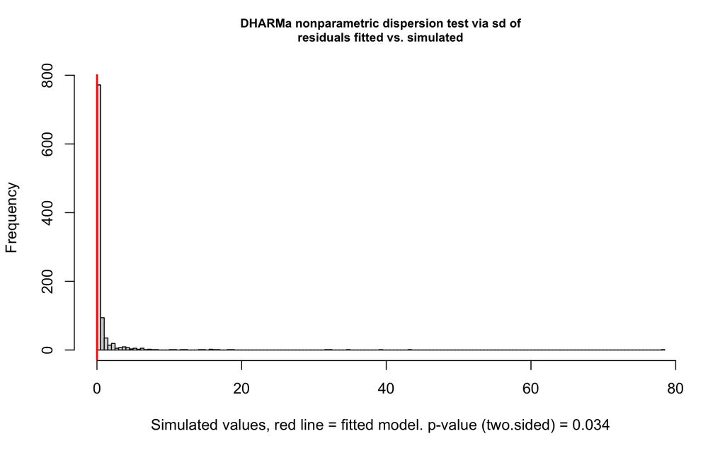

```
##
##  DHARMa nonparametric dispersion test via sd of residuals fitted vs.
##  simulated
##
## data:  simulationOutput
## dispersion = 0.0069224, p-value = 0.034
## alternative hypothesis: two.sided
```

```r
# --- PLOT MODEL RESIDUALS --- #

# Simulate residuals from the fitted model

simulationOutput <- simulateResiduals(fittedModel = model,
                                      n = 1000)

# Test for overdispersion in the model to check if variance exceeds mean

testDispersion(simulationOutput)
```

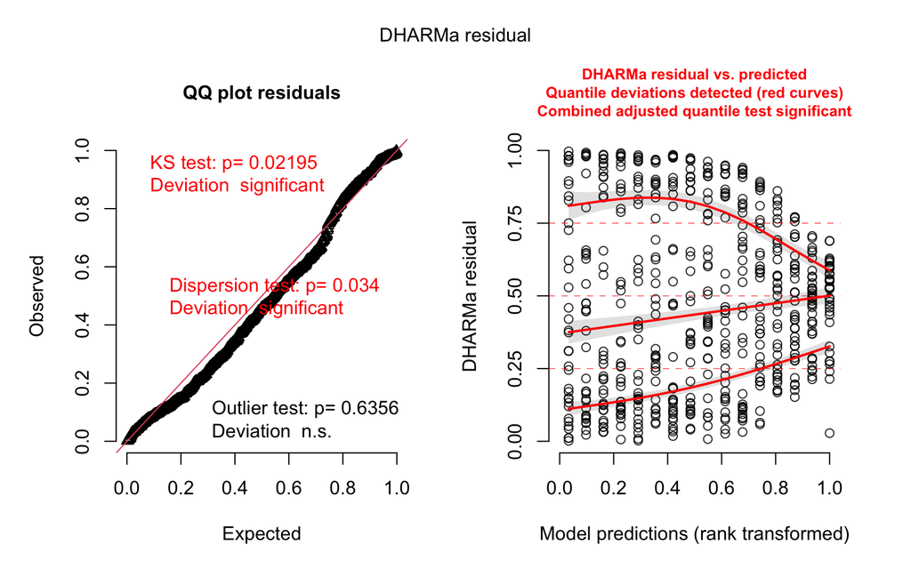

```r
# Plot Q-Q and Residuals vs Fitted plots

plot(simulationOutput)
```

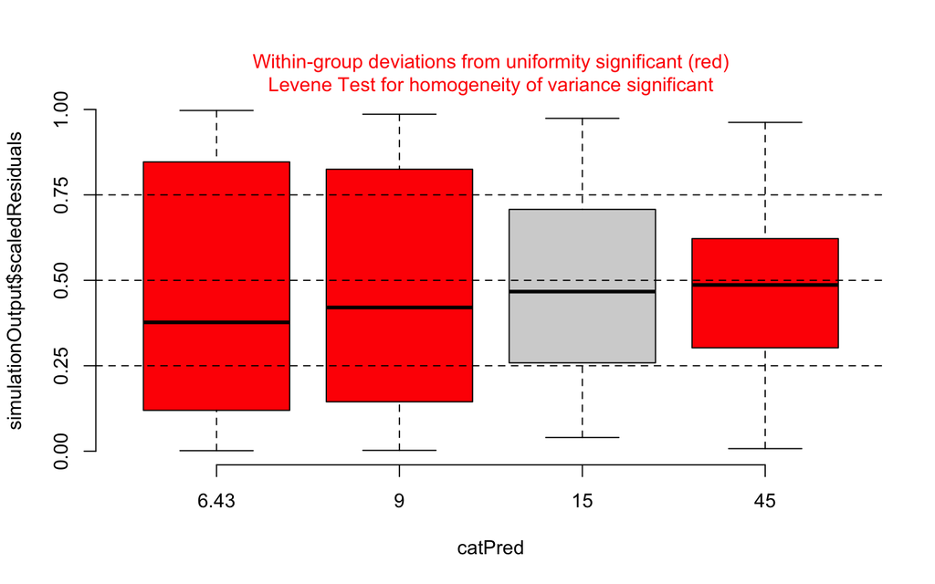

```r
# Plot residuals against specific predictors to check if residuals are
# independent of these variables - fixed variables

plotResiduals(simulationOutput,
              form = data_for_analysis$size)
```

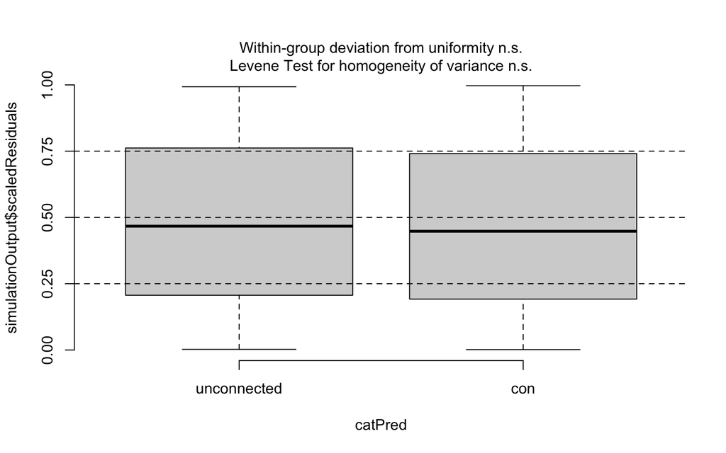

```r
plotResiduals(simulationOutput,
              form = data_for_analysis$conn)
```

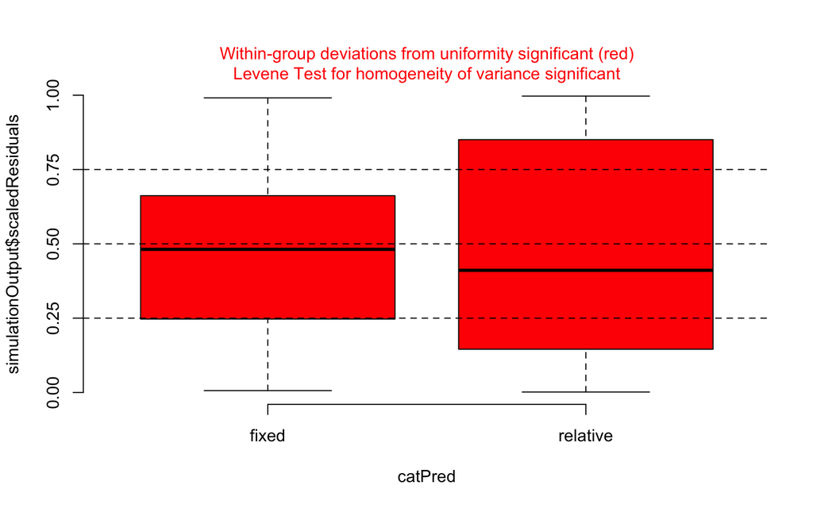

```r
plotResiduals(simulationOutput,
              form = data_for_analysis$disturb_type)
```

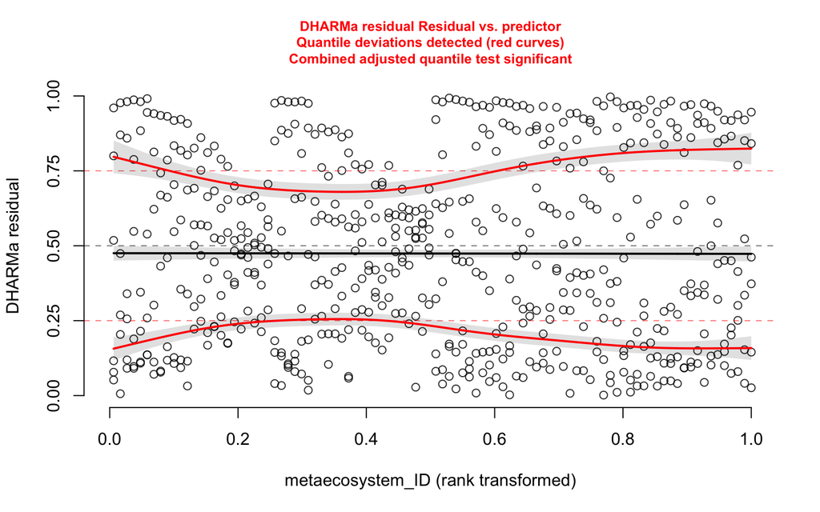

```r
# Plot residuals against specific predictors to check if residuals are
# independent of these variables - random variables

plotResiduals(simulationOutput,
              form = data_for_analysis$metaecosystem_ID)
```

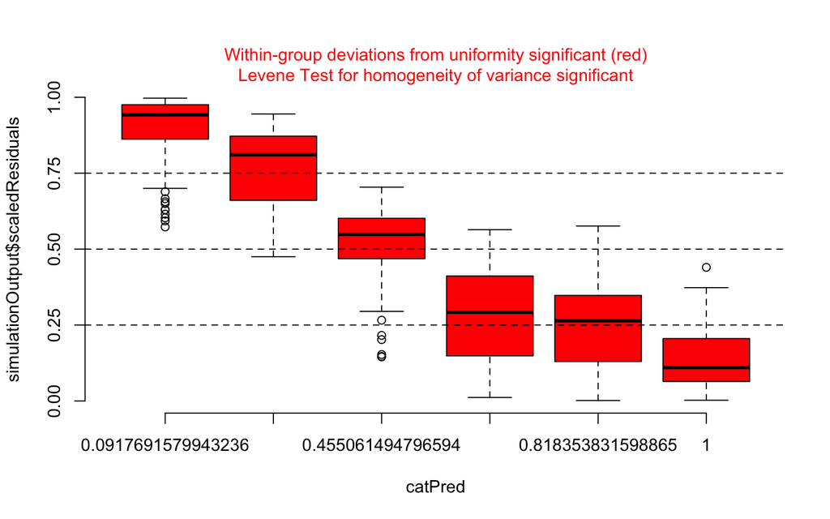

```r
plotResiduals(simulationOutput,
              form = data_for_analysis$time_point)
```

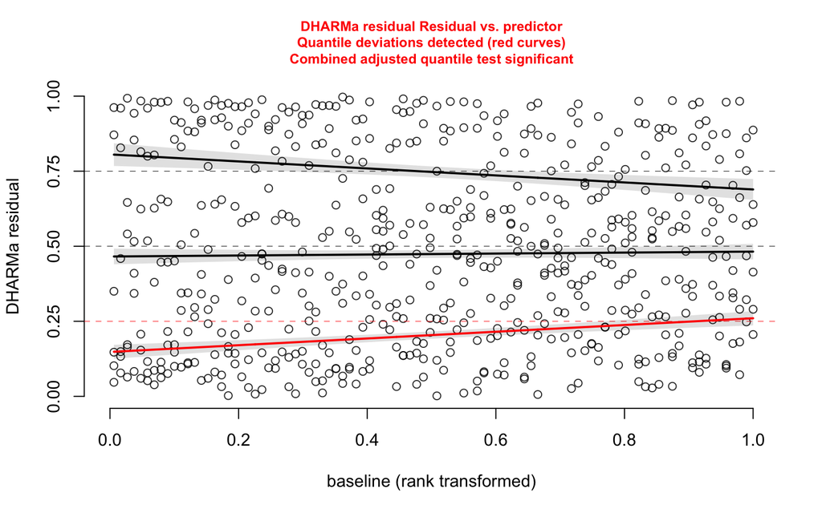

```r
plotResiduals(simulationOutput,
              form = data_for_analysis$baseline)
```

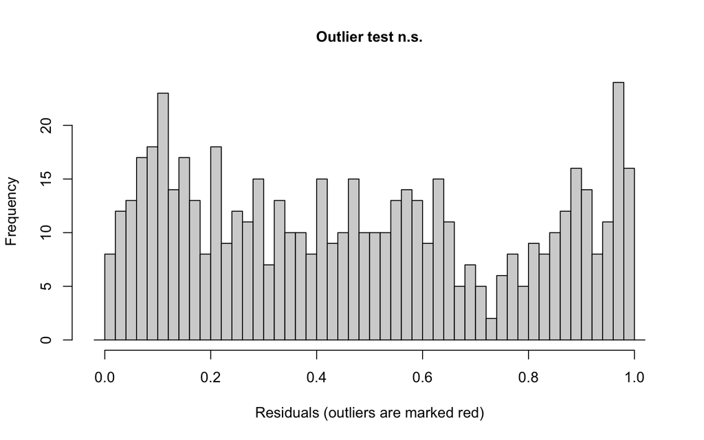

```
##
##  DHARMa outlier test based on exact binomial test with approximate
##  expectations
##
## data:  simulationOutput
## outliers at both margin(s) = 0, observations = 576, p-value = 0.6356
## alternative hypothesis: true probability of success is not equal to 0.001998002
## 95 percent confidence interval:
##  0.000000000 0.006383841
## sample estimates:
## frequency of outliers (expected: 0.001998001998002 )
##                                                    0
```

```r
# Test for outliers

testOutliers(simulationOutput)
```

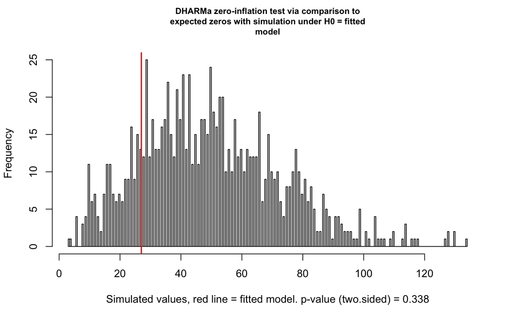

```
##
##  DHARMa zero-inflation test via comparison to expected zeros with
##  simulation under H0 = fitted model
##
## data:  simulationOutput
## ratioObsSim = 0.54267, p-value = 0.338
## alternative hypothesis: two.sided
```

```r
# Test for zero inflation not accounted for

testZeroInflation(simulationOutput)
```

```r
# Save figure according to Ecosphere guidelines

p <- plot.ecos.contrasts(contrasts,
                    trophic_type_selected,
                    response_variable_selected)

ggsave(
  filename = here("..", "3_results", "figures", "paper", "Autotrophic-ecosystems.tiff"),
  plot = p,
  device = "tiff",
  width = 18,
  height = 12,
  units = "cm",
  dpi = 600,
  compression = "lzw"
)
```

##### Without the smallest patches (6.43 ml)

As the smallest patches at the fixed and relative disturbance had the same disturbance level, I rerun the analysis to see if it’s robust to taking off these patch sizes.

```r
ds_ecosystems_without_6.43 = ds_ecosystems %>%
  filter(ecosystem_size_ml != 6.43)
```

```r
# --- DEFINE PARAMETERS --- #

response_variable_selected = "bioarea_mm2_per_ml"
```

**Prepare & plot data for analysis**

```r
# --- PREPARE DATA FOR ANALYSIS --- #

# Add baselines

baseline = ds_ecosystems_without_6.43 %>%
  filter(time_point == time_point_of_baselines) %>%
  select(ecosystem_ID,
         all_of(response_variable_selected)) %>%
  rename(baseline = all_of(response_variable_selected))

data_for_analysis = ds_ecosystems_without_6.43 %>%
  left_join(baseline)

# Filter and mutate

data_for_analysis = data_for_analysis %>%
  filter(time_point %in% time_points_model,
         !is.na(!!sym(response_variable_selected)),
         trophic_type == trophic_type_selected) %>%
  mutate(trophic_type = as.factor(trophic_type),
         size = as.factor(ecosystem_size_ml),
         conn = factor(x = ifelse(connection == "connected",
                                  "con",
                                  "unconnected"),
                       levels = c("unconnected", "con")),
         volume_disturbed_across_sizes = as.factor(volume_disturbed_across_sizes),
         day = as.double(day),
         ecosystem_ID = as.factor(ecosystem_ID))
```

**Rename disturbance type**

```r
# Prepare data

data_for_analysis = data_for_analysis %>%
  rename(disturb_type = volume_disturbed_across_sizes)
```

**Create model**

```r
# --- CREATE MODEL --- #

# Create formula

formula = as.formula(paste("bioarea_mm2_per_ml ~",
                           "size * conn * disturb_type +",
                           "(1 | day) +",
                           "(1 | baseline)")) %>%
  print()
```

```
## bioarea_mm2_per_ml ~ size * conn * disturb_type + (1 | day) +
##     (1 | baseline)
```

```r
# Model

model <- glmmTMB(formula,
                 data = data_for_analysis,
                 family = tweedie(link = "log"),
                 dispformula = ~ bioarea_mm2_per_ml)
car::Anova(model, type = "III")
```

```
## Analysis of Deviance Table (Type III Wald chisquare tests)
##
## Response: bioarea_mm2_per_ml
##                           Chisq Df Pr(>Chisq)
## (Intercept)              4.3880  1  0.0361931 *
## size                   126.7267  2  < 2.2e-16 ***
## conn                    15.3531  1  8.918e-05 ***
## disturb_type            57.2995  1  3.742e-14 ***
## size:conn                1.8702  2  0.3925448
## size:disturb_type       36.2021  2  1.377e-08 ***
## conn:disturb_type       13.2423  1  0.0002737 ***
## size:conn:disturb_type   7.6674  2  0.0216297 *
## ---
## Signif. codes:  0 '***' 0.001 '**' 0.01 '*' 0.05 '.' 0.1 ' ' 1
```

```r
# --- SHOW MODEL SUMMARY --- #

print(summary(model), digits = 3)
```

```
##  Family: tweedie  ( log )
## Formula:
## bioarea_mm2_per_ml ~ size * conn * disturb_type + (1 | day) +
##     (1 | baseline)
## Dispersion:                          ~bioarea_mm2_per_ml
## Data: data_for_analysis
##
##       AIC       BIC    logLik -2*log(L)  df.resid
##    1855.6    1924.8    -910.8    1821.6       415
##
## Random effects:
##
## Conditional model:
##  Groups   Name        Variance Std.Dev.
##  day      (Intercept) 1.50e+00 1.22e+00
##  baseline (Intercept) 2.34e-10 1.53e-05
## Number of obs: 432, groups:  day, 6; baseline, 72
##
## Conditional model:
##                                     Estimate Std. Error z value Pr(>|z|)
## (Intercept)                           1.0738     0.5126    2.09  0.03619 *
## size15                                1.0075     0.1557    6.47  9.7e-11 ***
## size45                                1.7940     0.1595   11.25  < 2e-16 ***
## conncon                               0.6038     0.1541    3.92  8.9e-05 ***
## disturb_typerelative                 -1.3015     0.1719   -7.57  3.7e-14 ***
## size15:conncon                        0.0105     0.2074    0.05  0.95980
## size45:conncon                       -0.2374     0.2103   -1.13  0.25888
## size15:disturb_typerelative          -1.0368     0.2339   -4.43  9.3e-06 ***
## size45:disturb_typerelative          -1.3392     0.2296   -5.83  5.5e-09 ***
## conncon:disturb_typerelative         -0.8696     0.2390   -3.64  0.00027 ***
## size15:conncon:disturb_typerelative   0.5823     0.3268    1.78  0.07479 .
## size45:conncon:disturb_typerelative   0.8853     0.3225    2.74  0.00605 **
## ---
## Signif. codes:  0 '***' 0.001 '**' 0.01 '*' 0.05 '.' 0.1 ' ' 1
##
## Dispersion model:
##                    Estimate Std. Error z value Pr(>|z|)
## (Intercept)         -0.7135     0.1043   -6.84  7.9e-12 ***
## bioarea_mm2_per_ml   0.0512     0.0105    4.89  1.0e-06 ***
## ---
## Signif. codes:  0 '***' 0.001 '**' 0.01 '*' 0.05 '.' 0.1 ' ' 1
```

```r
# --- CODE MODEL CONSTRASTS --- #

# Estimate marginal means (least-squares means)

emmeans_output = emmeans(model,
                         specs = ~  conn * disturb_type * size,
                         adjust = "sidak",
                         lmer.df = "satterthwaite")

emmeans_output
```

```
##  conn        disturb_type size  emmean    SE  df asymp.LCL asymp.UCL
##  unconnected fixed        9     1.0738 0.513 Inf    -0.391     2.539
##  con         fixed        9     1.6775 0.511 Inf     0.218     3.137
##  unconnected relative     9    -0.2278 0.519 Inf    -1.710     1.255
##  con         relative     9    -0.4936 0.520 Inf    -1.979     0.992
##  unconnected fixed        15    2.0813 0.510 Inf     0.623     3.540
##  con         fixed        15    2.6955 0.511 Inf     1.234     4.157
##  unconnected relative     15   -0.2570 0.517 Inf    -1.734     1.220
##  con         relative     15    0.0699 0.517 Inf    -1.406     1.546
##  unconnected fixed        45    2.8678 0.511 Inf     1.409     4.327
##  con         fixed        45    3.2341 0.512 Inf     1.770     4.698
##  unconnected relative     45    0.2271 0.514 Inf    -1.242     1.696
##  con         relative     45    0.6091 0.513 Inf    -0.858     2.076
##
## Results are given on the log (not the response) scale.
## Confidence level used: 0.95
## Conf-level adjustment: sidak method for 12 estimates
```

```r
# Give a name for each level which you want to compare

uncon_fixed_9 = c(1, rep(0,11))
con_fixed_9 = c(rep(0,1), 1, rep(0,10))
uncon_relative_9 = c(rep(0,2), 1, rep(0,9))
con_relative_9 = c(rep(0,3), 1, rep(0,8))
uncon_fixed_15 = c(rep(0,4), 1, rep(0,7))
con_fixed_15 = c(rep(0,5), 1, rep(0,6))
uncon_relative_15 = c(rep(0,6), 1, rep(0,5))
con_relative_15 = c(rep(0,7), 1, rep(0,4))
uncon_fixed_45 = c(rep(0,8), 1, rep(0,3))
con_fixed_45 = c(rep(0,9), 1, rep(0,2))
uncon_relative_45 = c(rep(0,10), 1, rep(0,1))
con_relative_45 = c(rep(0,11), 1)

# Compute the contrasts

contrasts = contrast(emmeans_output,
                     method = list("9.00 ml fixed" = con_fixed_9 - uncon_fixed_9,
                                   "15.00 ml fixed" = con_fixed_15 - uncon_fixed_15,
                                   "45.00 ml fixed" = con_fixed_45 - uncon_fixed_45,
                                   "9.00 ml relative" = con_relative_9 - uncon_relative_9,
                                   "15.00 ml relative" = con_relative_15 - uncon_relative_15,
                                   "45.00 ml relative" = con_relative_45 - uncon_relative_45),
                     type = "response")

nested_contrasts <- contrast(contrasts,
                             method = list(
                               "Difference in effects at 9.00 ml" = c(1, 0, 0, -1, 0, 0),
                               "Difference in effects at 15.00 ml" = c(0, 1, 0, 0, -1, 0),
                               "Difference in effects at 45.00 ml" = c(0, 0, 1, 0, 0, -1)))

# Tidy up contrasts

upper_CI = (confint(contrasts)$asymp.UCL - 1) * 100
lower_CI = (confint(contrasts)$asymp.LCL - 1) * 100

contrasts = contrasts %>%
  as.data.frame(.) %>%
  mutate(ratio = round(ratio, 2),
         percentage = (ratio-1)*100,
         SE = round(SE, 2),
         lower.CL = round(lower_CI, 2),  # Lower confidence limit
         upper.CL = round(upper_CI, 2),  # Upper confidence limit
         z.ratio = round(z.ratio, 2),
         p.value = round(p.value, 3)) %>%
  select(contrast,
         percentage,
         lower.CL,
         upper.CL,
         SE,
         z.ratio,
         p.value)

contrasts$" " <- ""
contrasts$" "[contrasts$p.value < 0.05] <- "*"
contrasts$" "[contrasts$p.value < 0.01] <- "**"
contrasts$" "[contrasts$p.value < 0.001] <- "***"

# Tidy up nested contrasts

upper_CI = (confint(nested_contrasts)$asymp.UCL - 1) * 100
lower_CI = (confint(nested_contrasts)$asymp.LCL - 1) * 100

nested_contrasts = nested_contrasts %>%
  as.data.frame(.) %>%
  mutate(ratio = round(ratio, 2),
         percentage = (ratio-1)*100,
         lower.CL = round(lower_CI, 2),  # Lower confidence limit
         upper.CL = round(upper_CI, 2),  # Upper confidence limit
         SE = round(SE, 2),
         z.ratio = round(z.ratio, 2),
         p.value = round(p.value, 3)) %>%
  select(contrast,
         percentage,
         lower.CL,
         upper.CL,
         SE,
         z.ratio,
         p.value)

nested_contrasts$" " <- ""
nested_contrasts$" "[nested_contrasts$p.value < 0.05] <- "*"
nested_contrasts$" "[nested_contrasts$p.value < 0.01] <- "**"
nested_contrasts$" "[nested_contrasts$p.value < 0.001] <- "***"
```

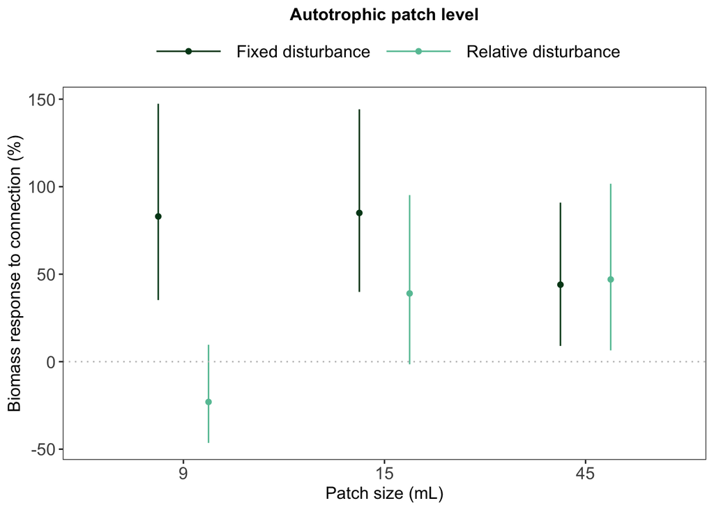

```r
plot.ecos.contrasts(contrasts,
                    trophic_type_selected,
                    response_variable_selected)
```

**Model ANOVA**

```r
# --- SHOW MODEL ANOVA --- #

car::Anova(model, type = "III")
```

```
## Analysis of Deviance Table (Type III Wald chisquare tests)
##
## Response: bioarea_mm2_per_ml
##                           Chisq Df Pr(>Chisq)
## (Intercept)              4.3880  1  0.0361931 *
## size                   126.7267  2  < 2.2e-16 ***
## conn                    15.3531  1  8.918e-05 ***
## disturb_type            57.2995  1  3.742e-14 ***
## size:conn                1.8702  2  0.3925448
## size:disturb_type       36.2021  2  1.377e-08 ***
## conn:disturb_type       13.2423  1  0.0002737 ***
## size:conn:disturb_type   7.6674  2  0.0216297 *
## ---
## Signif. codes:  0 '***' 0.001 '**' 0.01 '*' 0.05 '.' 0.1 ' ' 1
```

**Model contrasts**

```r
# --- SHOW MODEL CONTRASTS --- #

contrasts
```

```
##            contrast percentage lower.CL upper.CL   SE z.ratio p.value
## 1     9.00 ml fixed         83    35.22   147.38 0.28    3.92   0.000 ***
## 2    15.00 ml fixed         85    39.87   144.21 0.26    4.32   0.000 ***
## 3    45.00 ml fixed         44     9.00    90.89 0.21    2.56   0.010   *
## 4  9.00 ml relative        -23   -46.42     9.69 0.14   -1.45   0.146
## 5 15.00 ml relative         39    -1.48    95.18 0.24    1.87   0.061
## 6 45.00 ml relative         47     6.46   101.67 0.24    2.34   0.019   *
```

```r
nested_contrasts
```

```
##                            contrast percentage lower.CL upper.CL   SE z.ratio
## 1  Difference in effects at 9.00 ml        139    49.36   281.11 0.57    3.64
## 2 Difference in effects at 15.00 ml         33   -14.41   107.53 0.30    1.27
## 3 Difference in effects at 45.00 ml         -2   -35.58    50.43 0.21   -0.07
##   p.value
## 1   0.000 ***
## 2   0.204
## 3   0.942
```

**Model residuals**

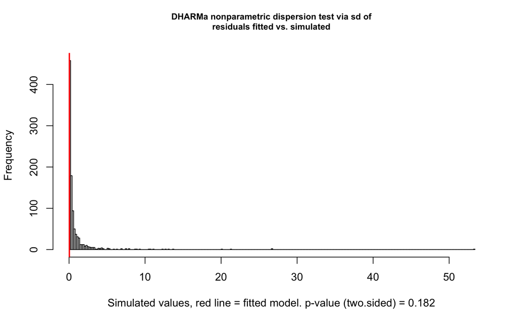

```
##
##  DHARMa nonparametric dispersion test via sd of residuals fitted vs.
##  simulated
##
## data:  simulationOutput
## dispersion = 0.044563, p-value = 0.182
## alternative hypothesis: two.sided
```

```r
# --- PLOT MODEL RESIDUALS --- #

# Simulate residuals from the fitted model

simulationOutput <- simulateResiduals(fittedModel = model,
                                      n = 1000)

# Test for overdispersion in the model to check if variance exceeds mean

testDispersion(simulationOutput)
```

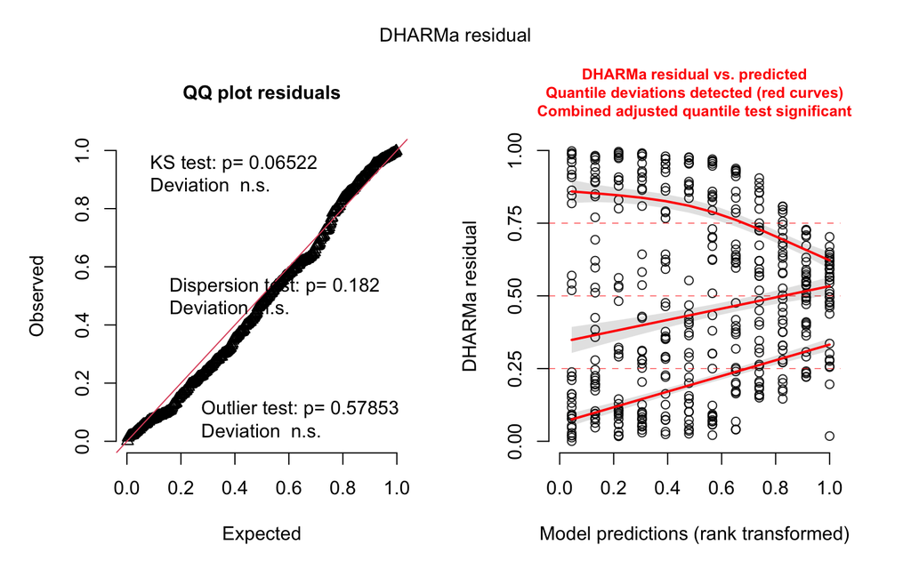

```r
# Plot Q-Q and Residuals vs Fitted plots

plot(simulationOutput)
```

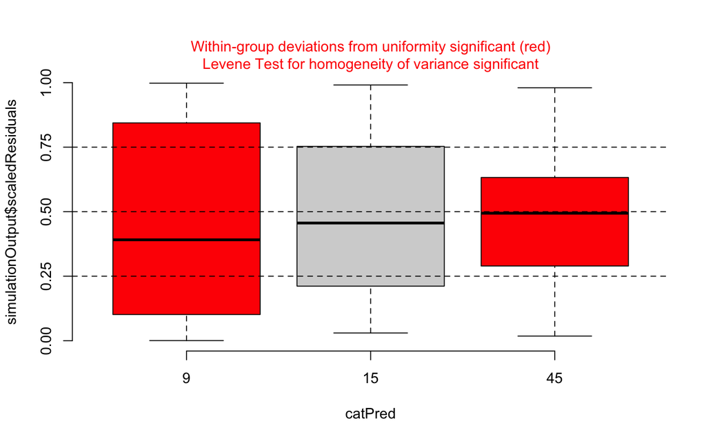

```r
# Plot residuals against specific predictors to check if residuals are
# independent of these variables - fixed variables

plotResiduals(simulationOutput,
              form = data_for_analysis$size)
```

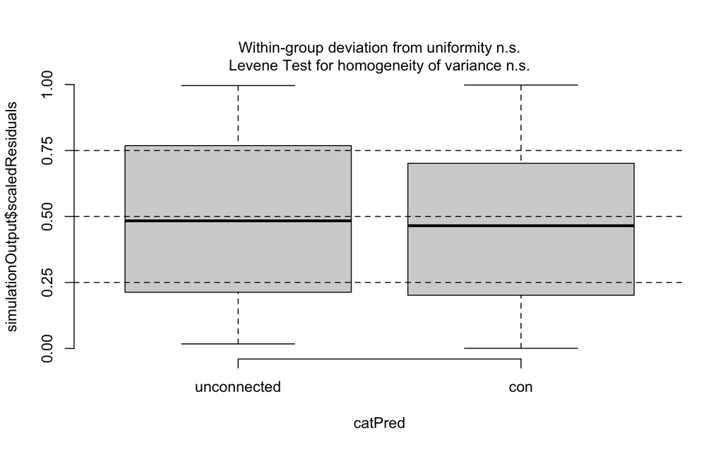

```r
plotResiduals(simulationOutput,
              form = data_for_analysis$conn)
```

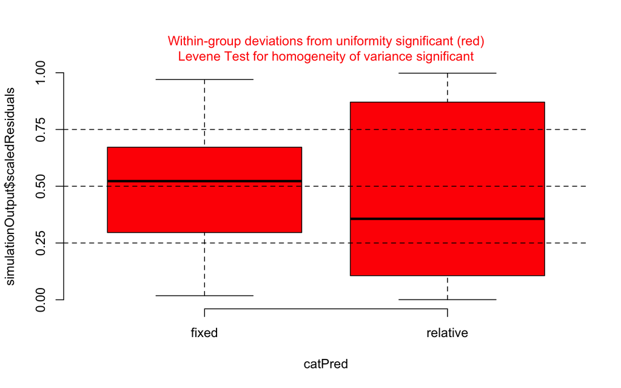

```r
plotResiduals(simulationOutput,
              form = data_for_analysis$disturb_type)
```

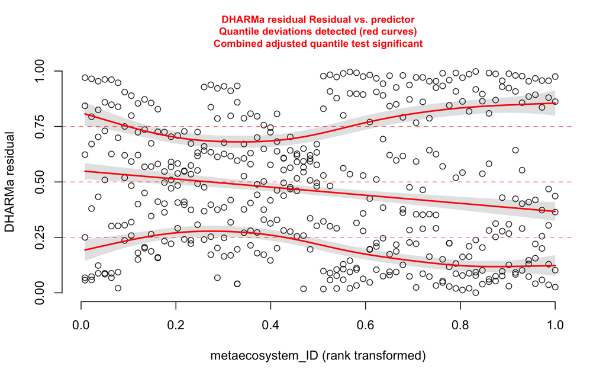

```r
# Plot residuals against specific predictors to check if residuals are
# independent of these variables - random variables

plotResiduals(simulationOutput,
              form = data_for_analysis$metaecosystem_ID)
```

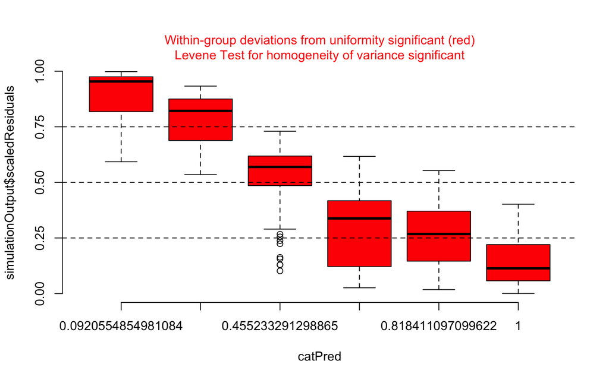

```r
plotResiduals(simulationOutput,
              form = data_for_analysis$time_point)
```

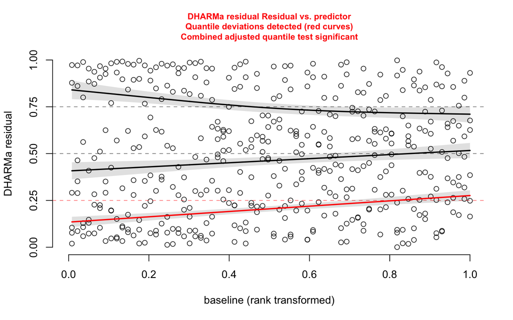

```r
plotResiduals(simulationOutput,
              form = data_for_analysis$baseline)
```

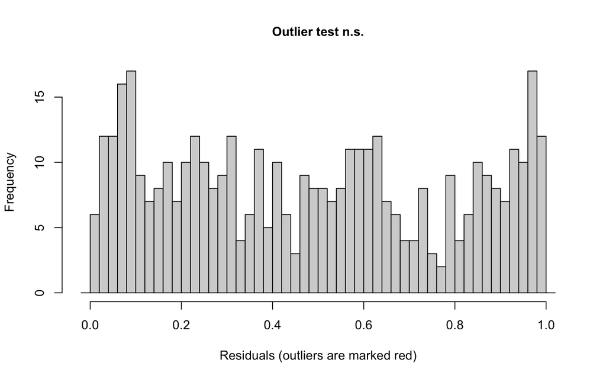

```
##
##  DHARMa outlier test based on exact binomial test with approximate
##  expectations
##
## data:  simulationOutput
## outliers at both margin(s) = 1, observations = 432, p-value = 0.5785
## alternative hypothesis: true probability of success is not equal to 0.001998002
## 95 percent confidence interval:
##  5.860432e-05 1.282929e-02
## sample estimates:
## frequency of outliers (expected: 0.001998001998002 )
##                                          0.002314815
```

```r
# Test for outliers

testOutliers(simulationOutput)
```

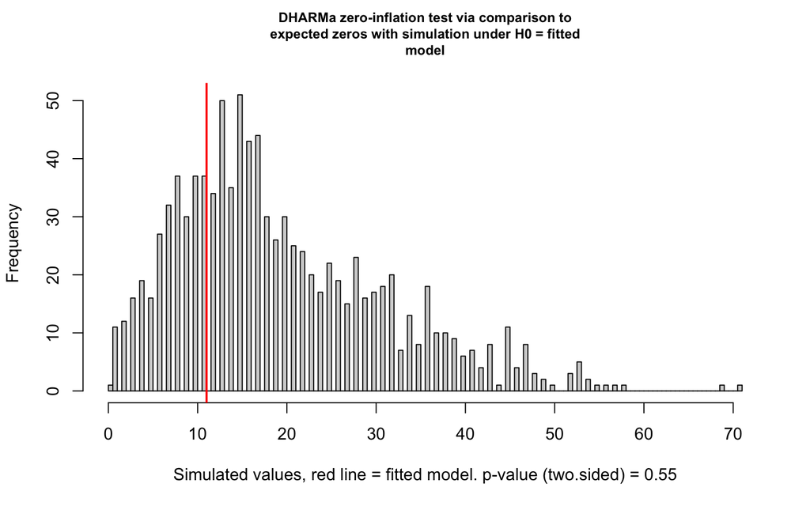

```
##
##  DHARMa zero-inflation test via comparison to expected zeros with
##  simulation under H0 = fitted model
##
## data:  simulationOutput
## ratioObsSim = 0.56226, p-value = 0.55
## alternative hypothesis: two.sided
```

```r
# Test for zero inflation not accounted for

testZeroInflation(simulationOutput)
```

#### Heterotrophic

```r
trophic_type_selected = "heterotrophic"
```

```r
# --- DEFINE PARAMETERS --- #

response_variable_selected = "bioarea_mm2_per_ml"
```

**Original data**

```r
# --- PLOT ONE PLOT PER ECOSYSTEM SIZE --- #

# Plot heterotrophic ecosystems

if(trophic_type_selected == "heterotrophic"){

  system_type_to_print = "Heterotrophic ecosystems"

  plot = plot.ecos.sizes.one.by.one.means(ds_ecosystems,
                                          "heterotrophic",
                                          response_variable_selected,
                                          light_colour_hetero,
                                          dark_colour_hetero,
                                          y_upper_limit = 6.2) +
    ggtitle("Heterotrophic patch level") +
    theme(plot.title = element_text(size = plot_title_size,
                                    face = plot_title_face,
                                    hjust = plot_title_hjust))
}

if(trophic_type_selected == "autotrophic"){

  # Plot autotrophic ecosystems

  system_type_to_print = "Autotrophic ecosystems"

  plot = plot.ecos.sizes.one.by.one.means(ds_ecosystems,
                                          "autotrophic",
                                          response_variable_selected,
                                          light_colour_auto,
                                          dark_colour_auto,
                                          y_upper_limit = 48) +
    ggtitle("Autotrophic patch level") +
    theme(plot.title = element_text(size = plot_title_size,
                                    face = plot_title_face,
                                    hjust = plot_title_hjust))

}

system_type_to_print
```

```
## [1] "Heterotrophic ecosystems"
```

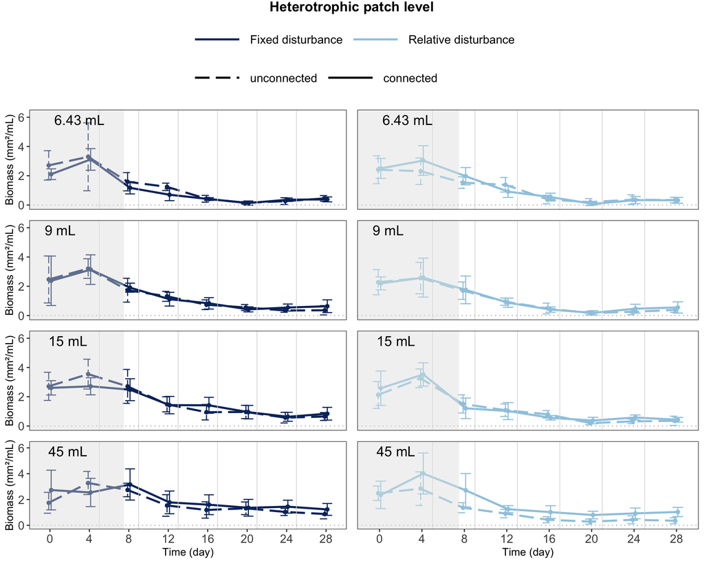

```r
plot
```

**Effect sizes**

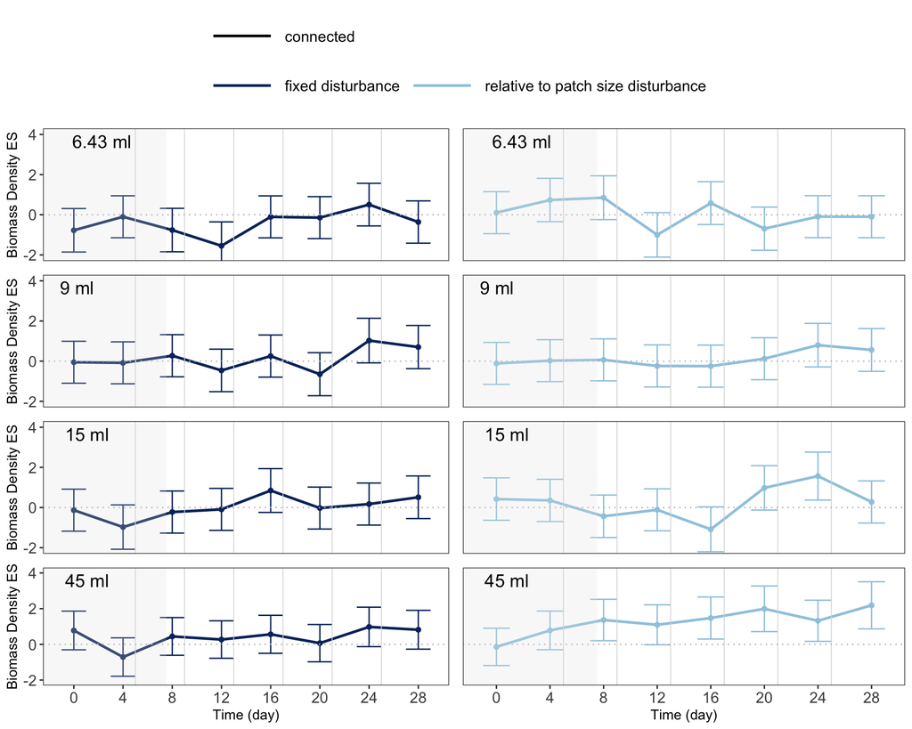

```r
if(trophic_type_selected == "heterotrophic"){
  plot.ecos.sizes.one.by.one.es(ds_ecosystems_effect_size,
                              trophic_type_selected,
                              response_variable_selected,
                              light_colour_hetero,
                              dark_colour_hetero,
                              y_upper_limit = 4,
                              legend_row_n_selected = 1,
                              y_lower_limit = -2)
}
```

```r
if(trophic_type_selected == "autotrophic"){
  plot.ecos.sizes.one.by.one.es(ds_ecosystems_effect_size,
                              trophic_type_selected,
                              response_variable_selected,
                              light_colour_auto,
                              dark_colour_auto,
                              y_upper_limit = 10,
                              legend_row_n_selected = 1,
                              y_lower_limit = -6)
}
```

**Prepare & plot data for analysis**

```r
# --- PREPARE DATA FOR ANALYSIS --- #

# Add baselines

baseline = ds_ecosystems %>%
  filter(time_point == time_point_of_baselines) %>%
  select(ecosystem_ID,
         all_of(response_variable_selected)) %>%
  rename(baseline = all_of(response_variable_selected))

data_for_analysis = ds_ecosystems %>%
  left_join(baseline)

# Filter and mutate

data_for_analysis = data_for_analysis %>%
  filter(time_point %in% time_points_model,
         !is.na(!!sym(response_variable_selected)),
         trophic_type == trophic_type_selected) %>%
  mutate(trophic_type = as.factor(trophic_type),
         size = as.factor(ecosystem_size_ml),
         conn = factor(x = ifelse(connection == "connected",
                                  "con",
                                  "unconnected"),
                       levels = c("unconnected", "con")),
         volume_disturbed_across_sizes = as.factor(volume_disturbed_across_sizes),
         day = as.double(day),
         ecosystem_ID = as.factor(ecosystem_ID))
```

```
## [1] "Heterotrophic ecosystems"
```

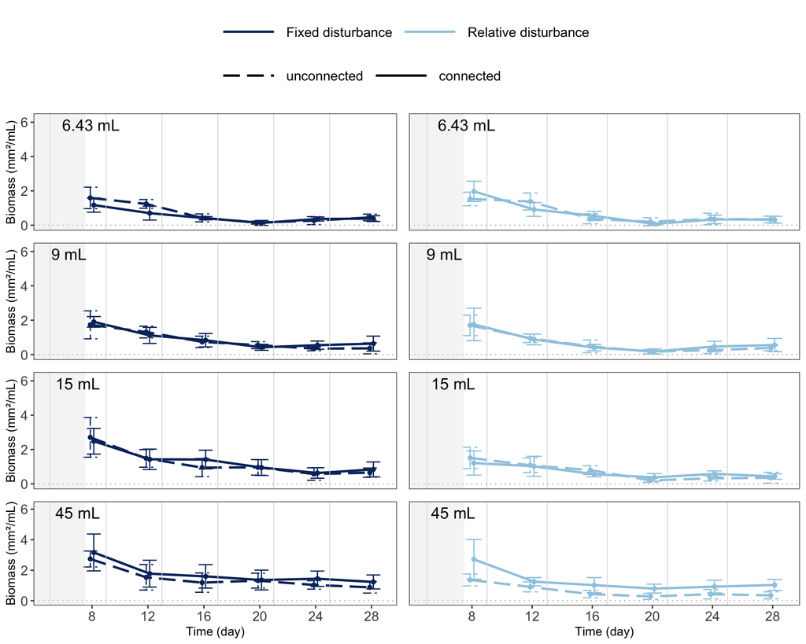

```r
# --- PLOT ONE PLOT PER ECOSYSTEM SIZE --- #

if(trophic_type_selected == "heterotrophic"){

  # Plot heterotrophic ecosystems

  print("Heterotrophic ecosystems")

  plot.ecos.sizes.one.by.one.means(data_for_analysis,
                                   "heterotrophic",
                                   response_variable_selected,
                                   light_colour_hetero,
                                   dark_colour_hetero,
                                   y_upper_limit = 6.2)

}
```

```r
if(trophic_type_selected == "autotrophic"){

  # Plot autotrophic ecosystems

  print("Autotrophic ecosystems")

  plot.ecos.sizes.one.by.one.means(data_for_analysis,
                                   "autotrophic",
                                   response_variable_selected,
                                   light_colour_auto,
                                   dark_colour_auto,
                                   y_upper_limit = 48)
}
```

**Rename disturbance type**

```r
# Prepare data

data_for_analysis = data_for_analysis %>%
  rename(disturb_type = volume_disturbed_across_sizes)
```

**Create model**

```r
# --- CREATE MODEL --- #

# Create formula

formula = as.formula(paste("bioarea_mm2_per_ml ~",
                           "size * conn * disturb_type +",
                           "(1 | day) +",
                           "(1 | baseline)")) %>%
  print()
```

```
## bioarea_mm2_per_ml ~ size * conn * disturb_type + (1 | day) +
##     (1 | baseline)
```

```r
# Model

model <- glmmTMB(formula,
                 data = data_for_analysis,
                 family = tweedie(link = "log"),
                 dispformula = ~ bioarea_mm2_per_ml)
car::Anova(model, type = "III")
```

```
## Analysis of Deviance Table (Type III Wald chisquare tests)
##
## Response: bioarea_mm2_per_ml
##                          Chisq Df Pr(>Chisq)
## (Intercept)             6.0378  1    0.01400 *
## size                   66.7298  3  2.139e-14 ***
## conn                    3.3696  1    0.06641 .
## disturb_type            0.0209  1    0.88513
## size:conn               7.6439  3    0.05397 .
## size:disturb_type      31.3076  3  7.322e-07 ***
## conn:disturb_type       1.3437  1    0.24638
## size:conn:disturb_type  9.5180  3    0.02314 *
## ---
## Signif. codes:  0 '***' 0.001 '**' 0.01 '*' 0.05 '.' 0.1 ' ' 1
```

```r
# --- SHOW MODEL SUMMARY --- #

print(summary(model), digits = 3)
```

```
##  Family: tweedie  ( log )
## Formula:
## bioarea_mm2_per_ml ~ size * conn * disturb_type + (1 | day) +
##     (1 | baseline)
## Dispersion:                          ~bioarea_mm2_per_ml
## Data: data_for_analysis
##
##       AIC       BIC    logLik -2*log(L)  df.resid
##     564.1     655.6    -261.1     522.1       555
##
## Random effects:
##
## Conditional model:
##  Groups   Name        Variance Std.Dev.
##  day      (Intercept) 2.49e-01 0.499305
##  baseline (Intercept) 1.70e-10 0.000013
## Number of obs: 576, groups:  day, 6; baseline, 96
##
## Conditional model:
##                                     Estimate Std. Error z value Pr(>|z|)
## (Intercept)                          -0.5488     0.2234   -2.46  0.01400 *
## size9                                 0.2259     0.1200    1.88  0.05971 .
## size15                                0.6086     0.1137    5.35  8.7e-08 ***
## size45                                0.8129     0.1113    7.30  2.8e-13 ***
## conncon                              -0.2386     0.1300   -1.84  0.06641 .
## disturb_typerelative                  0.0179     0.1240    0.14  0.88513
## size9:conncon                         0.3310     0.1722    1.92  0.05461 .
## size15:conncon                        0.3158     0.1638    1.93  0.05389 .
## size45:conncon                        0.4383     0.1597    2.74  0.00606 **
## size9:disturb_typerelative           -0.2989     0.1733   -1.72  0.08460 .
## size15:disturb_typerelative          -0.5759     0.1677   -3.43  0.00059 ***
## size45:disturb_typerelative          -0.8907     0.1672   -5.33  9.9e-08 ***
## conncon:disturb_typerelative          0.2089     0.1802    1.16  0.24638
## size9:conncon:disturb_typerelative   -0.2066     0.2463   -0.84  0.40166
## size15:conncon:disturb_typerelative  -0.2666     0.2392   -1.11  0.26499
## size45:conncon:disturb_typerelative   0.3341     0.2321    1.44  0.14989
## ---
## Signif. codes:  0 '***' 0.001 '**' 0.01 '*' 0.05 '.' 0.1 ' ' 1
##
## Dispersion model:
##                    Estimate Std. Error z value Pr(>|z|)
## (Intercept)         -1.6081     0.1319  -12.19   <2e-16 ***
## bioarea_mm2_per_ml   0.0188     0.1073    0.18     0.86
## ---
## Signif. codes:  0 '***' 0.001 '**' 0.01 '*' 0.05 '.' 0.1 ' ' 1
```

```r
# --- CODE MODEL CONSTRASTS --- #

# Estimate marginal means (least-squares means)

emmeans_output = emmeans(model,
                         specs = ~  conn * disturb_type * size,
                         adjust = "sidak",
                         lmer.df = "satterthwaite")

emmeans_output
```

```
##  conn        disturb_type size  emmean    SE  df asymp.LCL asymp.UCL
##  unconnected fixed        6.43 -0.5488 0.223 Inf    -1.207    0.1096
##  con         fixed        6.43 -0.7874 0.225 Inf    -1.452   -0.1230
##  unconnected relative     6.43 -0.5309 0.224 Inf    -1.190    0.1281
##  con         relative     6.43 -0.5606 0.225 Inf    -1.223    0.1016
##  unconnected fixed        9    -0.3229 0.221 Inf    -0.973    0.3271
##  con         fixed        9    -0.2304 0.219 Inf    -0.876    0.4152
##  unconnected relative     9    -0.6039 0.224 Inf    -1.264    0.0566
##  con         relative     9    -0.5091 0.224 Inf    -1.169    0.1505
##  unconnected fixed        15    0.0597 0.218 Inf    -0.583    0.7021
##  con         fixed        15    0.1370 0.216 Inf    -0.500    0.7743
##  unconnected relative     15   -0.4982 0.222 Inf    -1.154    0.1574
##  con         relative     15   -0.4788 0.222 Inf    -1.133    0.1751
##  unconnected fixed        45    0.2641 0.215 Inf    -0.370    0.8982
##  con         fixed        45    0.4638 0.214 Inf    -0.168    1.0954
##  unconnected relative     45   -0.6087 0.223 Inf    -1.267    0.0491
##  con         relative     45    0.1340 0.217 Inf    -0.505    0.7726
##
## Results are given on the log (not the response) scale.
## Confidence level used: 0.95
## Conf-level adjustment: sidak method for 16 estimates
```

```r
# Give a name for each level which you want to compare

uncon_fixed_6_43 = c(1, rep(0,15))
con_fixed_6_43 = c(rep(0,1), 1, rep(0,14))
uncon_relative_6_43 = c(rep(0,2), 1, rep(0,13))
con_relative_6_43 = c(rep(0,3), 1, rep(0,12))
uncon_fixed_9 = c(rep(0,4), 1, rep(0,11))
con_fixed_9 = c(rep(0,5), 1, rep(0,10))
uncon_relative_9 = c(rep(0,6), 1, rep(0,9))
con_relative_9 = c(rep(0,7), 1, rep(0,8))
uncon_fixed_15 = c(rep(0,8), 1, rep(0,7))
con_fixed_15 = c(rep(0,9), 1, rep(0,6))
uncon_relative_15 = c(rep(0,10), 1, rep(0,5))
con_relative_15 = c(rep(0,11), 1, rep(0,4))
uncon_fixed_45 = c(rep(0,12), 1, rep(0,3))
con_fixed_45 = c(rep(0,13), 1, rep(0,2))
uncon_relative_45 = c(rep(0,14), 1, rep(0,1))
con_relative_45 = c(rep(0,15), 1)

# Compute the contrasts

contrasts = contrast(emmeans_output,
                     method = list("6.43 ml fixed" = con_fixed_6_43 - uncon_fixed_6_43,
                                   "9.00 ml fixed" = con_fixed_9 - uncon_fixed_9,
                                   "15.00 ml fixed" = con_fixed_15 - uncon_fixed_15,
                                   "45.00 ml fixed" = con_fixed_45 - uncon_fixed_45,
                                   "6.43 ml relative" = con_relative_6_43 - uncon_relative_6_43,
                                   "9.00 ml relative" = con_relative_9 - uncon_relative_9,
                                   "15.00 ml relative" = con_relative_15 - uncon_relative_15,
                                   "45.00 ml relative" = con_relative_45 - uncon_relative_45),
                     type = "response")

nested_contrasts <- contrast(contrasts,
                             method = list(
                               "Difference in effects at 6.43 ml" = c(1, 0, 0, 0, -1, 0, 0, 0),
                               "Difference in effects at 9.00 ml" = c(0, 1, 0, 0, 0, -1, 0, 0),
                               "Difference in effects at 15.00 ml" = c(0, 0, 1, 0, 0, 0, -1, 0),
                               "Difference in effects at 45.00 ml" = c(0, 0, 0, 1, 0, 0, 0, -1)))

# Tidy up contrasts

upper_CI = (confint(contrasts)$asymp.UCL - 1) * 100
lower_CI = (confint(contrasts)$asymp.LCL - 1) * 100

contrasts = contrasts %>%
  as.data.frame(.) %>%
  mutate(ratio = round(ratio, 2),
         percentage = (ratio-1)*100,
         SE = round(SE, 2),
         lower.CL = round(lower_CI, 2),  # Lower confidence limit
         upper.CL = round(upper_CI, 2),  # Upper confidence limit
         z.ratio = round(z.ratio, 2),
         p.value = round(p.value, 3)) %>%
  select(contrast,
         percentage,
         lower.CL,
         upper.CL,
         SE,
         z.ratio,
         p.value)

contrasts$" " <- ""
contrasts$" "[contrasts$p.value < 0.05] <- "*"
contrasts$" "[contrasts$p.value < 0.01] <- "**"
contrasts$" "[contrasts$p.value < 0.001] <- "***"

# Tidy up nested contrasts

upper_CI = (confint(nested_contrasts)$asymp.UCL - 1) * 100
lower_CI = (confint(nested_contrasts)$asymp.LCL - 1) * 100

nested_contrasts = nested_contrasts %>%
  as.data.frame(.) %>%
  mutate(ratio = round(ratio, 2),
         percentage = (ratio-1)*100,
         lower.CL = round(lower_CI, 2),  # Lower confidence limit
         upper.CL = round(upper_CI, 2),  # Upper confidence limit
         SE = round(SE, 2),
         z.ratio = round(z.ratio, 2),
         p.value = round(p.value, 3)) %>%
  select(contrast,
         percentage,
         lower.CL,
         upper.CL,
         SE,
         z.ratio,
         p.value)

nested_contrasts$" " <- ""
nested_contrasts$" "[nested_contrasts$p.value < 0.05] <- "*"
nested_contrasts$" "[nested_contrasts$p.value < 0.01] <- "**"
nested_contrasts$" "[nested_contrasts$p.value < 0.001] <- "***"
```

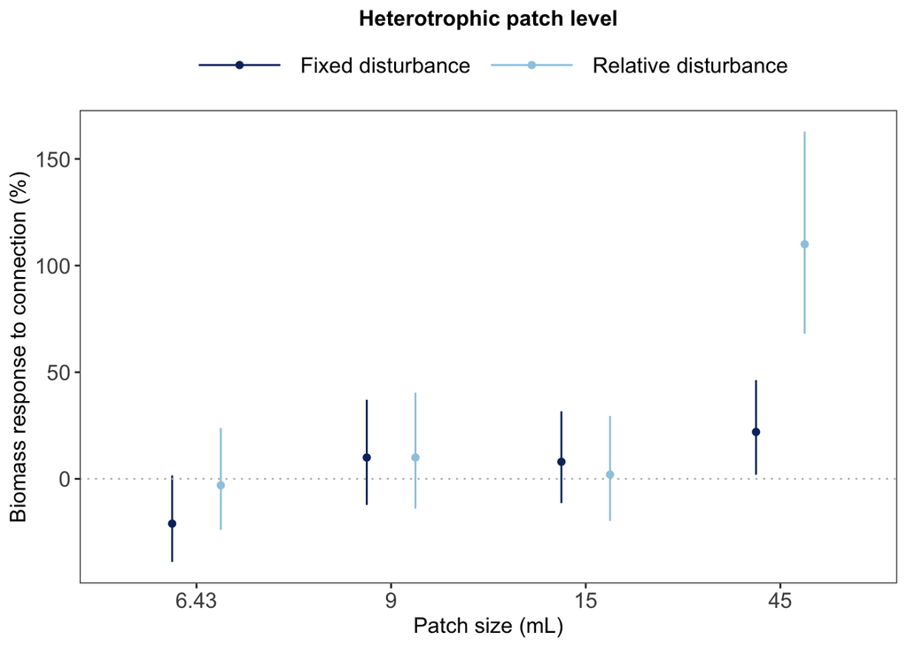

```r
plot.ecos.contrasts(contrasts,
                    trophic_type_selected,
                    response_variable_selected)
```

**Model ANOVA**

```r
# --- SHOW MODEL ANOVA --- #

car::Anova(model, type = "III")
```

```
## Analysis of Deviance Table (Type III Wald chisquare tests)
##
## Response: bioarea_mm2_per_ml
##                          Chisq Df Pr(>Chisq)
## (Intercept)             6.0378  1    0.01400 *
## size                   66.7298  3  2.139e-14 ***
## conn                    3.3696  1    0.06641 .
## disturb_type            0.0209  1    0.88513
## size:conn               7.6439  3    0.05397 .
## size:disturb_type      31.3076  3  7.322e-07 ***
## conn:disturb_type       1.3437  1    0.24638
## size:conn:disturb_type  9.5180  3    0.02314 *
## ---
## Signif. codes:  0 '***' 0.001 '**' 0.01 '*' 0.05 '.' 0.1 ' ' 1
```

**Model contrasts**

```r
# --- SHOW MODEL CONTRASTS --- #

contrasts
```

```
##            contrast percentage lower.CL upper.CL   SE z.ratio p.value
## 1     6.43 ml fixed        -21   -38.94     1.63 0.10   -1.84   0.066
## 2     9.00 ml fixed         10   -12.24    37.09 0.12    0.81   0.416
## 3    15.00 ml fixed          8   -11.36    31.67 0.11    0.77   0.444
## 4    45.00 ml fixed         22     1.92    46.29 0.11    2.17   0.030   *
## 5  6.43 ml relative         -3   -23.92    23.86 0.12   -0.24   0.811
## 6  9.00 ml relative         10   -13.93    40.42 0.14    0.76   0.448
## 7 15.00 ml relative          2   -19.70    29.48 0.12    0.16   0.873
## 8 45.00 ml relative        110    68.06   162.81 0.24    6.51   0.000 ***
```

```r
nested_contrasts
```

```
##                            contrast percentage lower.CL upper.CL   SE z.ratio
## 1  Difference in effects at 6.43 ml        -19   -42.99    15.52 0.15   -1.16
## 2  Difference in effects at 9.00 ml          0   -28.39    39.02 0.17   -0.01
## 3 Difference in effects at 15.00 ml          6   -22.26    44.39 0.17    0.37
## 4 Difference in effects at 45.00 ml        -42   -56.39   -22.60 0.09   -3.71
##   p.value
## 1   0.246
## 2   0.989
## 3   0.715
## 4   0.000 ***
```

**Model residuals**

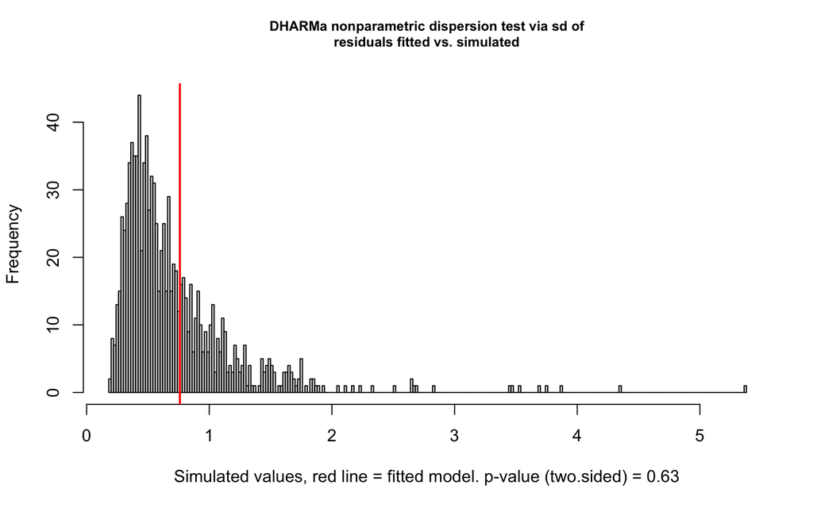

```
##
##  DHARMa nonparametric dispersion test via sd of residuals fitted vs.
##  simulated
##
## data:  simulationOutput
## dispersion = 1.0672, p-value = 0.63
## alternative hypothesis: two.sided
```

```r
# --- PLOT MODEL RESIDUALS --- #

# Simulate residuals from the fitted model

simulationOutput <- simulateResiduals(fittedModel = model,
                                      n = 1000)

# Test for overdispersion in the model to check if variance exceeds mean

testDispersion(simulationOutput)
```

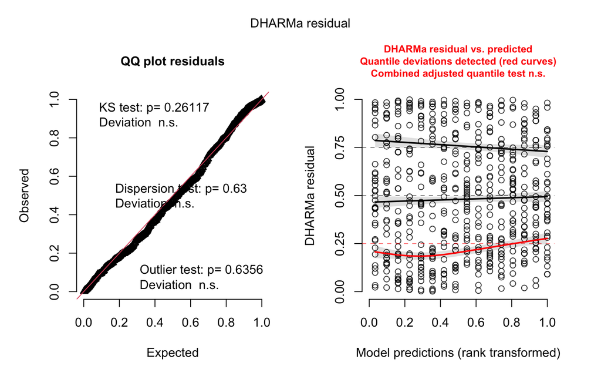

```r
# Plot Q-Q and Residuals vs Fitted plots

plot(simulationOutput)
```

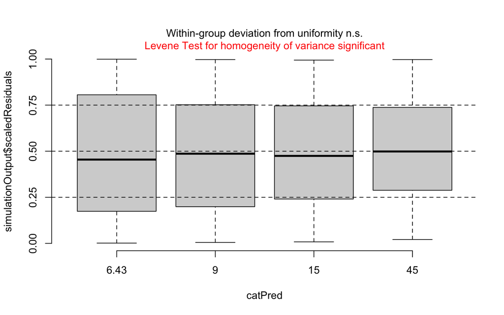

```r
# Plot residuals against specific predictors to check if residuals are
# independent of these variables - fixed variables

plotResiduals(simulationOutput,
              form = data_for_analysis$size)
```

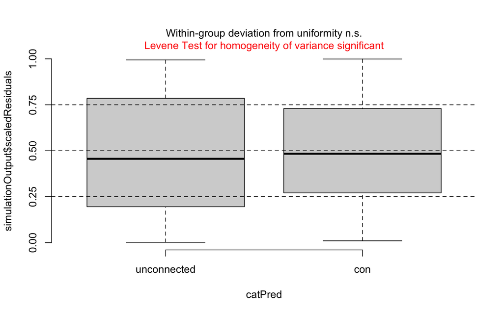

```r
plotResiduals(simulationOutput,
              form = data_for_analysis$conn)
```

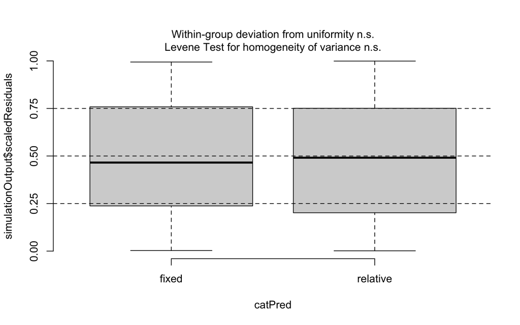

```r
plotResiduals(simulationOutput,
              form = data_for_analysis$disturb_type)
```

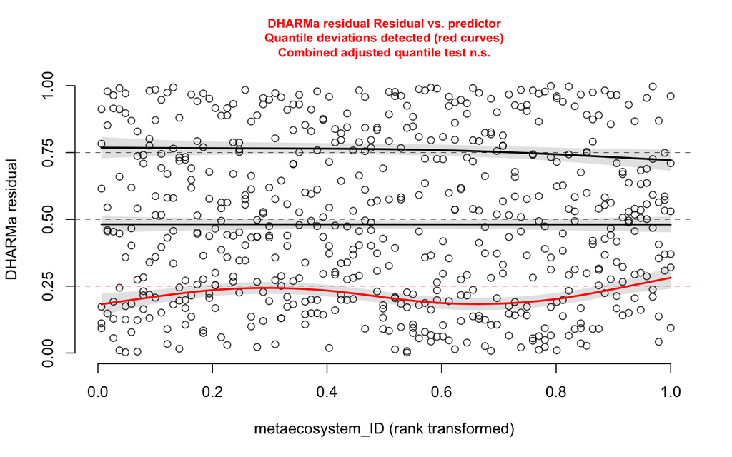

```r
# Plot residuals against specific predictors to check if residuals are
# independent of these variables - random variables

plotResiduals(simulationOutput,
              form = data_for_analysis$metaecosystem_ID)
```

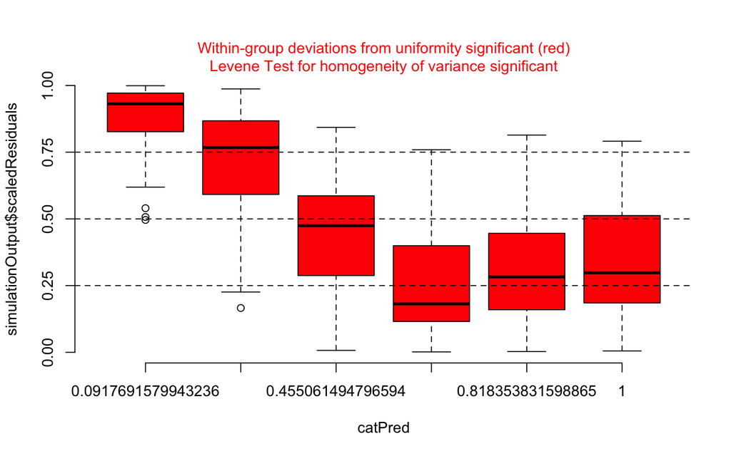

```r
plotResiduals(simulationOutput,
              form = data_for_analysis$time_point)
```

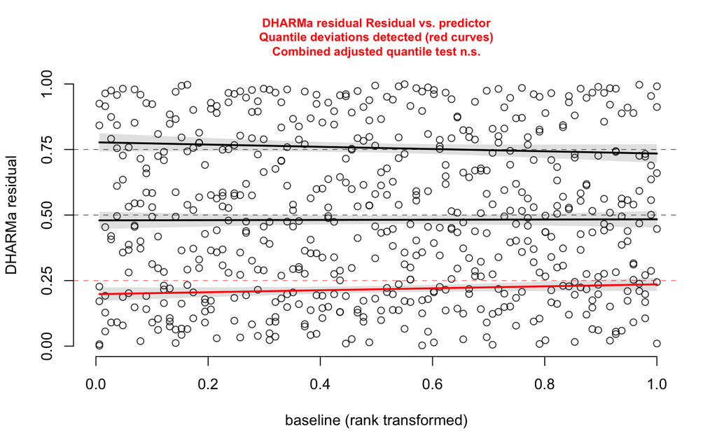

```r
plotResiduals(simulationOutput,
              form = data_for_analysis$baseline)
```

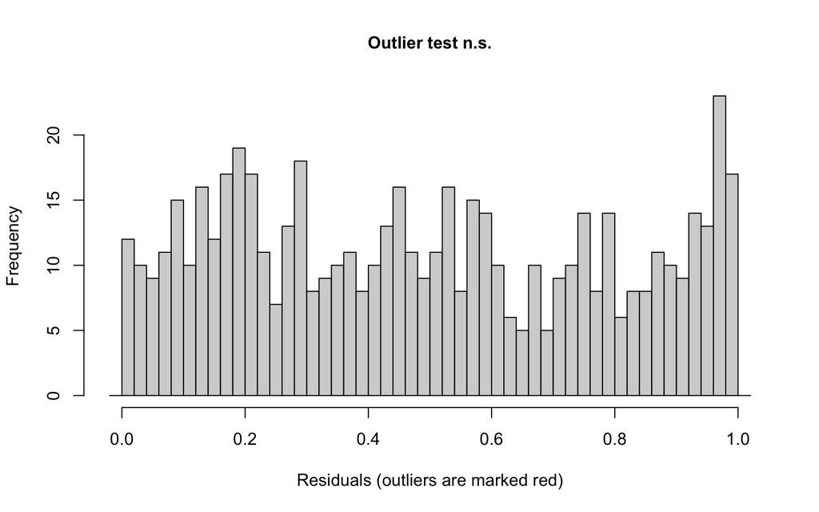

```
##
##  DHARMa outlier test based on exact binomial test with approximate
##  expectations
##
## data:  simulationOutput
## outliers at both margin(s) = 0, observations = 576, p-value = 0.6356
## alternative hypothesis: true probability of success is not equal to 0.001998002
## 95 percent confidence interval:
##  0.000000000 0.006383841
## sample estimates:
## frequency of outliers (expected: 0.001998001998002 )
##                                                    0
```

```r
# Test for outliers

testOutliers(simulationOutput)
```

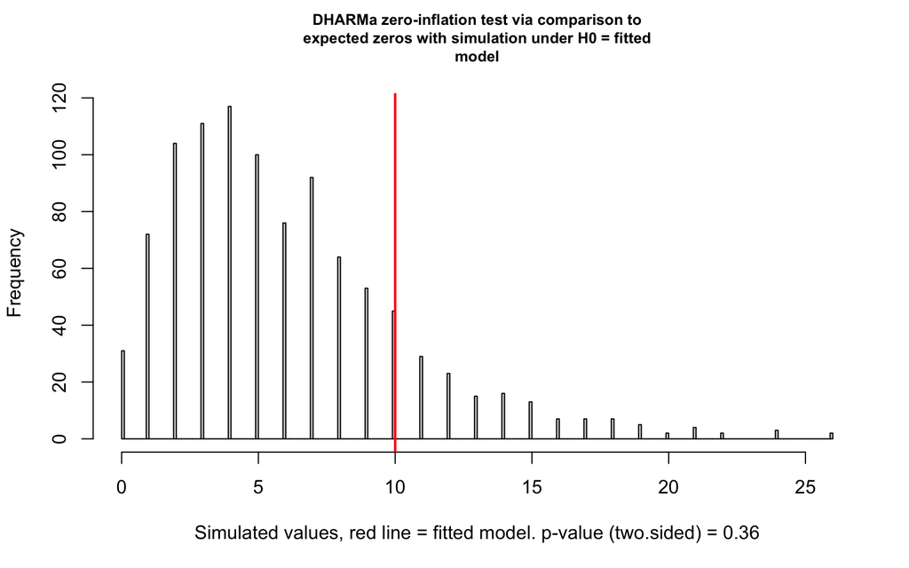

```
##
##  DHARMa zero-inflation test via comparison to expected zeros with
##  simulation under H0 = fitted model
##
## data:  simulationOutput
## ratioObsSim = 1.6466, p-value = 0.36
## alternative hypothesis: two.sided
```

```r
# Test for zero inflation not accounted for

testZeroInflation(simulationOutput)
```

```r
# Save figure according to Ecosphere guidelines

p <- plot.ecos.contrasts(contrasts,
                         trophic_type_selected,
                         response_variable_selected)

ggsave(
  filename = here("..", "3_results", "figures", "paper", "Heterotrophic_ecosystems.tiff"),
  plot = p,
  device = "tiff",
  width = 18,
  height = 12,
  units = "cm",
  dpi = 600,
  compression = "lzw"
)
```

##### Without the smallest patches (6.43 ml)

As the smallest patches at the fixed and relative disturbance had the same disturbance level, I rerun the analysis to see if it’s robust to taking off these patch sizes.

```r
ds_ecosystems_without_6.43 = ds_ecosystems %>%
  filter(ecosystem_size_ml != 6.43)
```

```r
# --- DEFINE PARAMETERS --- #

response_variable_selected = "bioarea_mm2_per_ml"
```

**Prepare & plot data for analysis**

```r
# --- PREPARE DATA FOR ANALYSIS --- #

# Add baselines

baseline = ds_ecosystems_without_6.43 %>%
  filter(time_point == time_point_of_baselines) %>%
  select(ecosystem_ID,
         all_of(response_variable_selected)) %>%
  rename(baseline = all_of(response_variable_selected))

data_for_analysis = ds_ecosystems_without_6.43 %>%
  left_join(baseline)

# Filter and mutate

data_for_analysis = data_for_analysis %>%
  filter(time_point %in% time_points_model,
         !is.na(!!sym(response_variable_selected)),
         trophic_type == trophic_type_selected) %>%
  mutate(trophic_type = as.factor(trophic_type),
         size = as.factor(ecosystem_size_ml),
         conn = factor(x = ifelse(connection == "connected",
                                  "con",
                                  "unconnected"),
                       levels = c("unconnected", "con")),
         volume_disturbed_across_sizes = as.factor(volume_disturbed_across_sizes),
         day = as.double(day),
         ecosystem_ID = as.factor(ecosystem_ID))
```

**Rename disturbance type**

```r
# Prepare data

data_for_analysis = data_for_analysis %>%
  rename(disturb_type = volume_disturbed_across_sizes)
```

**Create model**

```r
# --- CREATE MODEL --- #

# Create formula

formula = as.formula(paste("bioarea_mm2_per_ml ~",
                           "size * conn * disturb_type +",
                           "(1 | day) +",
                           "(1 | baseline)")) %>%
  print()
```

```
## bioarea_mm2_per_ml ~ size * conn * disturb_type + (1 | day) +
##     (1 | baseline)
```

```r
# Model

model <- glmmTMB(formula,
                 data = data_for_analysis,
                 family = tweedie(link = "log"),
                 dispformula = ~ bioarea_mm2_per_ml)
car::Anova(model, type = "III")
```

```
## Analysis of Deviance Table (Type III Wald chisquare tests)
##
## Response: bioarea_mm2_per_ml
##                          Chisq Df Pr(>Chisq)
## (Intercept)             2.5223  1   0.112246
## size                   31.8885  2   1.19e-07 ***
## conn                    0.7766  1   0.378190
## disturb_type            5.6193  1   0.017764 *
## size:conn               0.7890  2   0.674013
## size:disturb_type      13.3797  2   0.001243 **
## conn:disturb_type       0.0027  1   0.958509
## size:conn:disturb_type  9.9326  2   0.006969 **
## ---
## Signif. codes:  0 '***' 0.001 '**' 0.01 '*' 0.05 '.' 0.1 ' ' 1
```

```r
# --- SHOW MODEL SUMMARY --- #

print(summary(model), digits = 3)
```

```
##  Family: tweedie  ( log )
## Formula:
## bioarea_mm2_per_ml ~ size * conn * disturb_type + (1 | day) +
##     (1 | baseline)
## Dispersion:                          ~bioarea_mm2_per_ml
## Data: data_for_analysis
##
##       AIC       BIC    logLik -2*log(L)  df.resid
##     463.2     532.4    -214.6     429.2       415
##
## Random effects:
##
## Conditional model:
##  Groups   Name        Variance Std.Dev.
##  day      (Intercept) 2.04e-01 4.51e-01
##  baseline (Intercept) 1.81e-10 1.35e-05
## Number of obs: 432, groups:  day, 6; baseline, 72
##
## Conditional model:
##                                     Estimate Std. Error z value Pr(>|z|)
## (Intercept)                         -0.32147    0.20241   -1.59  0.11225
## size15                               0.37536    0.10738    3.50  0.00047 ***
## size45                               0.58746    0.10428    5.63  1.8e-08 ***
## conncon                              0.09812    0.11134    0.88  0.37819
## disturb_typerelative                -0.28019    0.11820   -2.37  0.01776 *
## size15:conncon                      -0.01349    0.14908   -0.09  0.92791
## size45:conncon                       0.09828    0.14509    0.68  0.49817
## size15:disturb_typerelative         -0.26819    0.16210   -1.65  0.09803 .
## size45:disturb_typerelative         -0.58686    0.16120   -3.64  0.00027 ***
## conncon:disturb_typerelative        -0.00861    0.16544   -0.05  0.95851
## size15:conncon:disturb_typerelative -0.05578    0.22583   -0.25  0.80491
## size45:conncon:disturb_typerelative  0.54659    0.21935    2.49  0.01271 *
## ---
## Signif. codes:  0 '***' 0.001 '**' 0.01 '*' 0.05 '.' 0.1 ' ' 1
##
## Dispersion model:
##                    Estimate Std. Error z value Pr(>|z|)
## (Intercept)         -1.7401     0.1766   -9.85   <2e-16 ***
## bioarea_mm2_per_ml   0.0935     0.1381    0.68      0.5
## ---
## Signif. codes:  0 '***' 0.001 '**' 0.01 '*' 0.05 '.' 0.1 ' ' 1
```

```r
# --- CODE MODEL CONSTRASTS --- #

# Estimate marginal means (least-squares means)

emmeans_output = emmeans(model,
                         specs = ~  conn * disturb_type * size,
                         adjust = "sidak",
                         lmer.df = "satterthwaite")

emmeans_output
```

```
##  conn        disturb_type size  emmean    SE  df asymp.LCL asymp.UCL
##  unconnected fixed        9    -0.3215 0.202 Inf    -0.900    0.2570
##  con         fixed        9    -0.2234 0.200 Inf    -0.796    0.3496
##  unconnected relative     9    -0.6017 0.206 Inf    -1.191   -0.0126
##  con         relative     9    -0.5122 0.206 Inf    -1.102    0.0775
##  unconnected fixed        15    0.0539 0.201 Inf    -0.520    0.6276
##  con         fixed        15    0.1385 0.198 Inf    -0.428    0.7047
##  unconnected relative     15   -0.4945 0.204 Inf    -1.078    0.0891
##  con         relative     15   -0.4743 0.203 Inf    -1.055    0.1069
##  unconnected fixed        45    0.2660 0.197 Inf    -0.297    0.8292
##  con         fixed        45    0.4624 0.197 Inf    -0.100    1.0248
##  unconnected relative     45   -0.6011 0.204 Inf    -1.185   -0.0168
##  con         relative     45    0.1333 0.199 Inf    -0.435    0.7014
##
## Results are given on the log (not the response) scale.
## Confidence level used: 0.95
## Conf-level adjustment: sidak method for 12 estimates
```

```r
# Give a name for each level which you want to compare

uncon_fixed_9 = c(1, rep(0,11))
con_fixed_9 = c(rep(0,1), 1, rep(0,10))
uncon_relative_9 = c(rep(0,2), 1, rep(0,9))
con_relative_9 = c(rep(0,3), 1, rep(0,8))
uncon_fixed_15 = c(rep(0,4), 1, rep(0,7))
con_fixed_15 = c(rep(0,5), 1, rep(0,6))
uncon_relative_15 = c(rep(0,6), 1, rep(0,5))
con_relative_15 = c(rep(0,7), 1, rep(0,4))
uncon_fixed_45 = c(rep(0,8), 1, rep(0,3))
con_fixed_45 = c(rep(0,9), 1, rep(0,2))
uncon_relative_45 = c(rep(0,10), 1, rep(0,1))
con_relative_45 = c(rep(0,11), 1)

# Compute the contrasts

contrasts = contrast(emmeans_output,
                     method = list("9.00 ml fixed" = con_fixed_9 - uncon_fixed_9,
                                   "15.00 ml fixed" = con_fixed_15 - uncon_fixed_15,
                                   "45.00 ml fixed" = con_fixed_45 - uncon_fixed_45,
                                   "9.00 ml relative" = con_relative_9 - uncon_relative_9,
                                   "15.00 ml relative" = con_relative_15 - uncon_relative_15,
                                   "45.00 ml relative" = con_relative_45 - uncon_relative_45),
                     type = "response")

nested_contrasts <- contrast(contrasts,
                             method = list(
                               "Difference in effects at 9.00 ml" = c(1, 0, 0, -1, 0, 0),
                               "Difference in effects at 15.00 ml" = c(0, 1, 0, 0, -1, 0),
                               "Difference in effects at 45.00 ml" = c(0, 0, 1, 0, 0, -1)))

# Tidy up contrasts

upper_CI = (confint(contrasts)$asymp.UCL - 1) * 100
lower_CI = (confint(contrasts)$asymp.LCL - 1) * 100

contrasts = contrasts %>%
  as.data.frame(.) %>%
  mutate(ratio = round(ratio, 2),
         percentage = (ratio-1)*100,
         SE = round(SE, 2),
         lower.CL = round(lower_CI, 2),  # Lower confidence limit
         upper.CL = round(upper_CI, 2),  # Upper confidence limit
         z.ratio = round(z.ratio, 2),
         p.value = round(p.value, 3)) %>%
  select(contrast,
         percentage,
         lower.CL,
         upper.CL,
         SE,
         z.ratio,
         p.value)

contrasts$" " <- ""
contrasts$" "[contrasts$p.value < 0.05] <- "*"
contrasts$" "[contrasts$p.value < 0.01] <- "**"
contrasts$" "[contrasts$p.value < 0.001] <- "***"

# Tidy up nested contrasts

upper_CI = (confint(nested_contrasts)$asymp.UCL - 1) * 100
lower_CI = (confint(nested_contrasts)$asymp.LCL - 1) * 100

nested_contrasts = nested_contrasts %>%
  as.data.frame(.) %>%
  mutate(ratio = round(ratio, 2),
         percentage = (ratio-1)*100,
         lower.CL = round(lower_CI, 2),  # Lower confidence limit
         upper.CL = round(upper_CI, 2),  # Upper confidence limit
         SE = round(SE, 2),
         z.ratio = round(z.ratio, 2),
         p.value = round(p.value, 3)) %>%
  select(contrast,
         percentage,
         lower.CL,
         upper.CL,
         SE,
         z.ratio,
         p.value)

nested_contrasts$" " <- ""
nested_contrasts$" "[nested_contrasts$p.value < 0.05] <- "*"
nested_contrasts$" "[nested_contrasts$p.value < 0.01] <- "**"
nested_contrasts$" "[nested_contrasts$p.value < 0.001] <- "***"
```

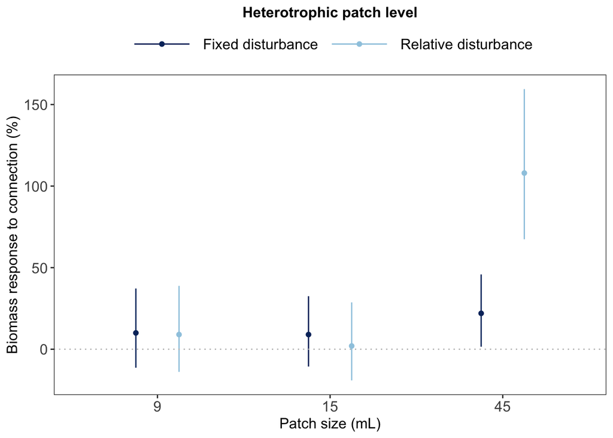

```r
plot.ecos.contrasts(contrasts,
                    trophic_type_selected,
                    response_variable_selected)
```

**Model ANOVA**

```r
# --- SHOW MODEL ANOVA --- #

car::Anova(model, type = "III")
```

```
## Analysis of Deviance Table (Type III Wald chisquare tests)
##
## Response: bioarea_mm2_per_ml
##                          Chisq Df Pr(>Chisq)
## (Intercept)             2.5223  1   0.112246
## size                   31.8885  2   1.19e-07 ***
## conn                    0.7766  1   0.378190
## disturb_type            5.6193  1   0.017764 *
## size:conn               0.7890  2   0.674013
## size:disturb_type      13.3797  2   0.001243 **
## conn:disturb_type       0.0027  1   0.958509
## size:conn:disturb_type  9.9326  2   0.006969 **
## ---
## Signif. codes:  0 '***' 0.001 '**' 0.01 '*' 0.05 '.' 0.1 ' ' 1
```

**Model contrasts**

```r
# --- SHOW MODEL CONTRASTS --- #

contrasts
```

```
##            contrast percentage lower.CL upper.CL   SE z.ratio p.value
## 1     9.00 ml fixed         10   -11.32    37.21 0.12    0.88   0.378
## 2    15.00 ml fixed          9   -10.61    32.50 0.11    0.84   0.399
## 3    45.00 ml fixed         22     1.55    45.85 0.11    2.13   0.033   *
## 4  9.00 ml relative          9   -13.86    38.84 0.13    0.74   0.462
## 5 15.00 ml relative          2   -19.10    28.72 0.12    0.17   0.864
## 6 45.00 ml relative        108    67.42   159.45 0.23    6.57   0.000 ***
```

```r
nested_contrasts
```

```
##                            contrast percentage lower.CL upper.CL   SE z.ratio
## 1  Difference in effects at 9.00 ml          1   -27.07    39.50 0.17    0.05
## 2 Difference in effects at 15.00 ml          7   -21.28    44.49 0.17    0.42
## 3 Difference in effects at 45.00 ml        -42   -56.01   -22.50 0.08   -3.72
##   p.value
## 1   0.959
## 2   0.678
## 3   0.000 ***
```

**Model residuals**

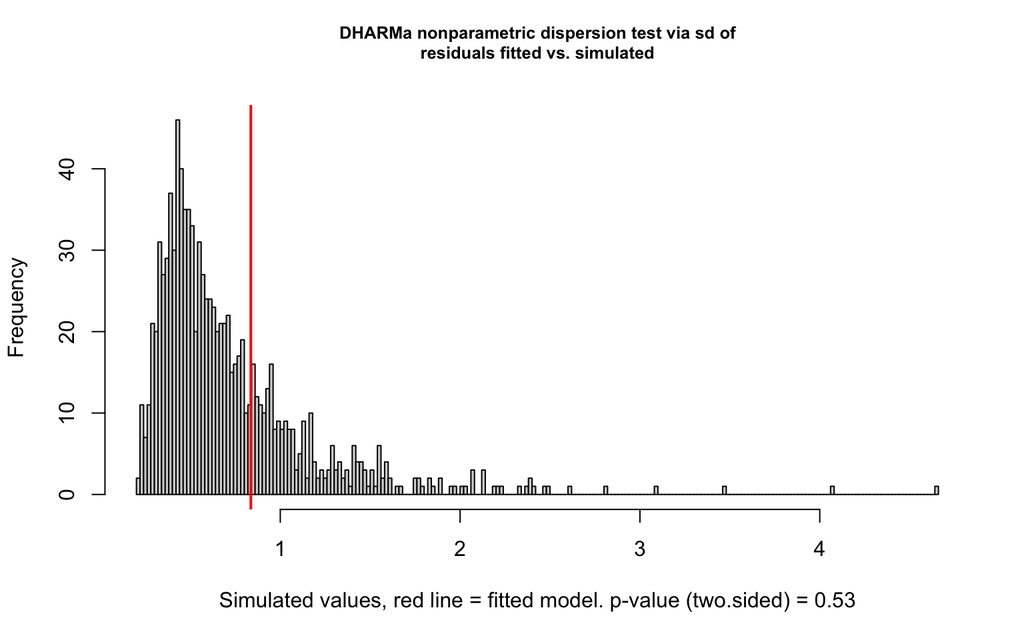

```
##
##  DHARMa nonparametric dispersion test via sd of residuals fitted vs.
##  simulated
##
## data:  simulationOutput
## dispersion = 1.1719, p-value = 0.53
## alternative hypothesis: two.sided
```

```r
# --- PLOT MODEL RESIDUALS --- #

# Simulate residuals from the fitted model

simulationOutput <- simulateResiduals(fittedModel = model,
                                      n = 1000)

# Test for overdispersion in the model to check if variance exceeds mean

testDispersion(simulationOutput)
```

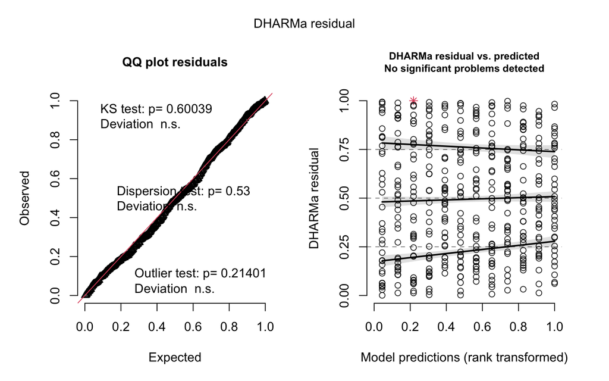

```r
# Plot Q-Q and Residuals vs Fitted plots

plot(simulationOutput)
```

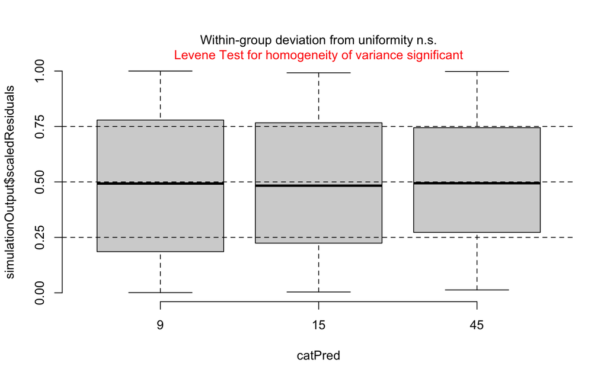

```r
# Plot residuals against specific predictors to check if residuals are
# independent of these variables - fixed variables

plotResiduals(simulationOutput,
              form = data_for_analysis$size)
```

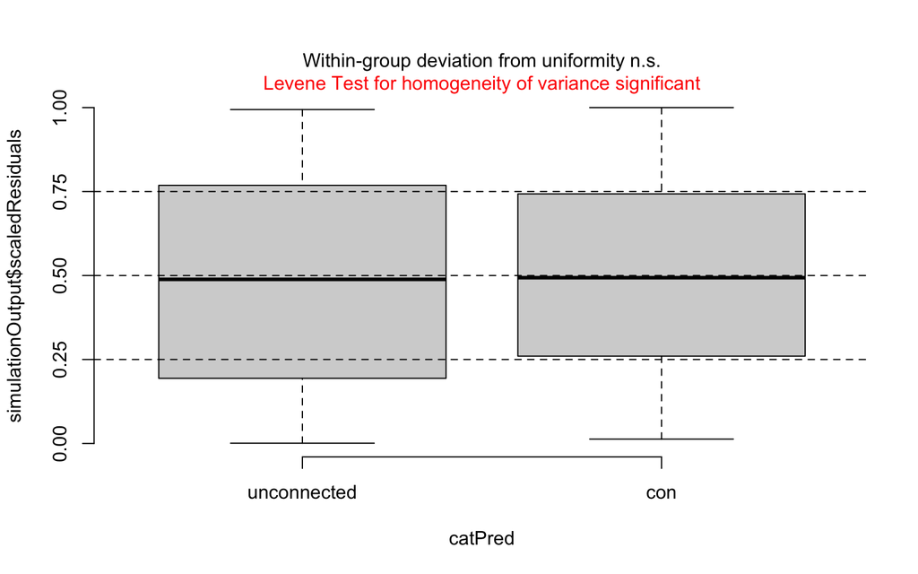

```r
plotResiduals(simulationOutput,
              form = data_for_analysis$conn)
```

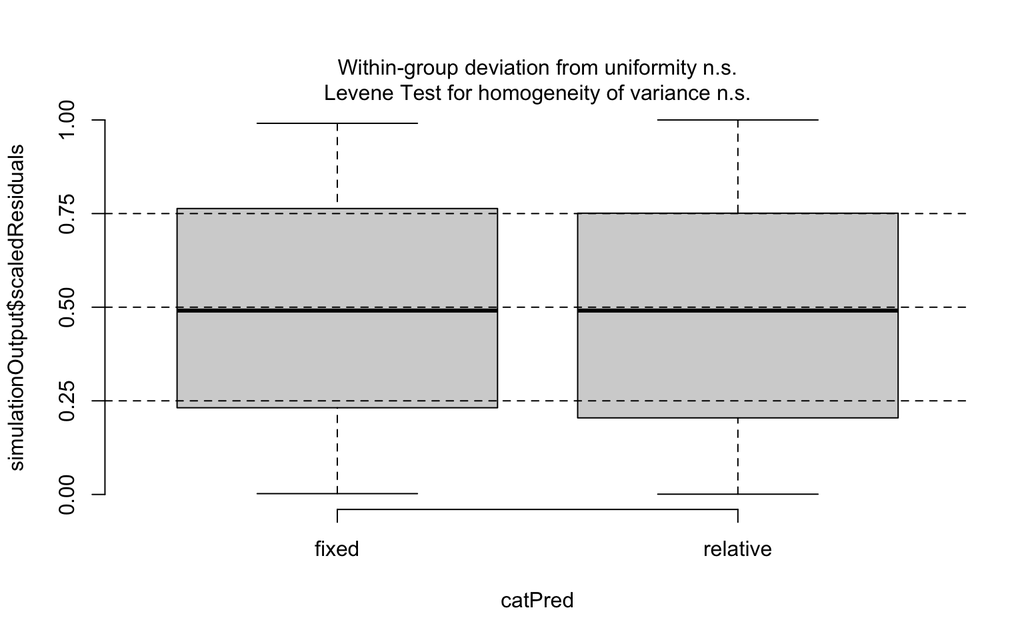

```r
plotResiduals(simulationOutput,
              form = data_for_analysis$disturb_type)
```

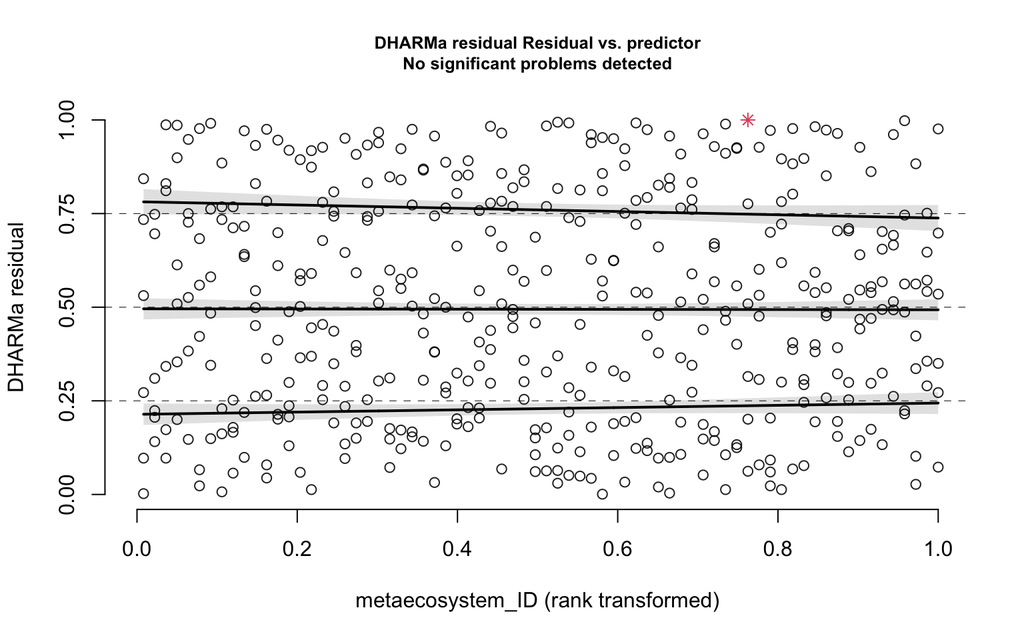

```r
# Plot residuals against specific predictors to check if residuals are
# independent of these variables - random variables

plotResiduals(simulationOutput,
              form = data_for_analysis$metaecosystem_ID)
```

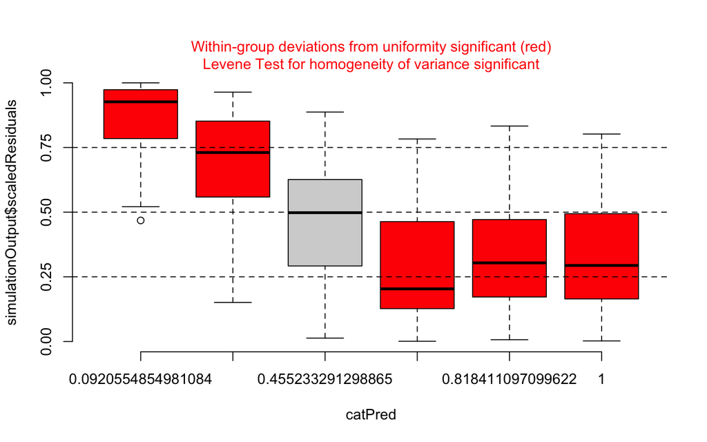

```r
plotResiduals(simulationOutput,
              form = data_for_analysis$time_point)
```

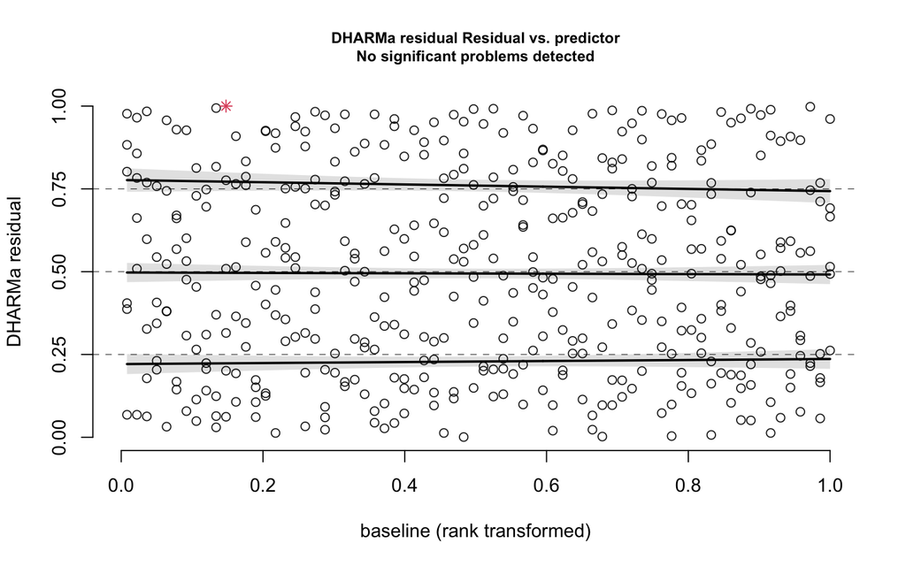

```r
plotResiduals(simulationOutput,
              form = data_for_analysis$baseline)
```

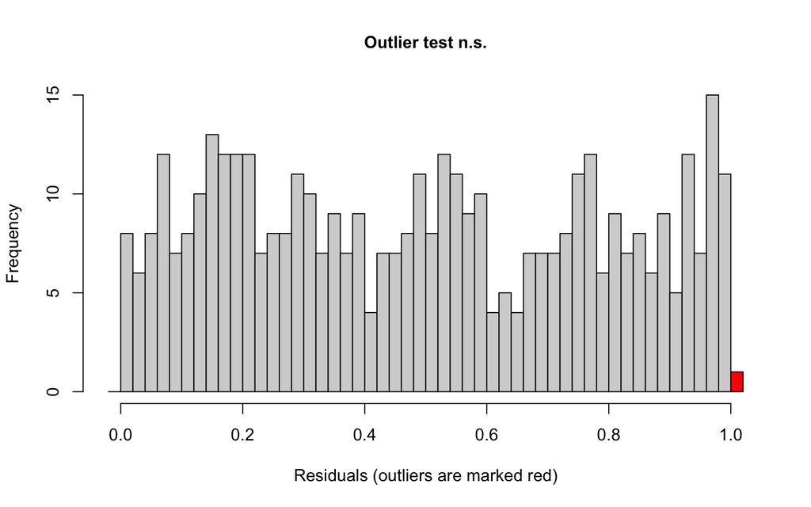

```
##
##  DHARMa outlier test based on exact binomial test with approximate
##  expectations
##
## data:  simulationOutput
## outliers at both margin(s) = 2, observations = 432, p-value = 0.214
## alternative hypothesis: true probability of success is not equal to 0.001998002
## 95 percent confidence interval:
##  0.0005611622 0.0166229885
## sample estimates:
## frequency of outliers (expected: 0.001998001998002 )
##                                           0.00462963
```

```r
# Test for outliers

testOutliers(simulationOutput)
```

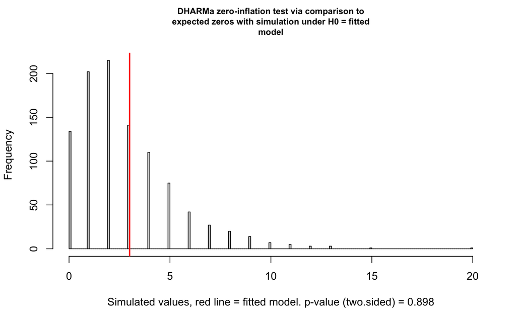

```
##
##  DHARMa zero-inflation test via comparison to expected zeros with
##  simulation under H0 = fitted model
##
## data:  simulationOutput
## ratioObsSim = 1.0593, p-value = 0.898
## alternative hypothesis: two.sided
```

```r
# Test for zero inflation not accounted for

testZeroInflation(simulationOutput)
```

### Shannon

```r
response_variable_selected = "shannon"
y_upper_limit_selected = 2
```

### Simpson

```r
response_variable_selected = "simpson"
y_upper_limit_selected = 1
```

### Species Richness

```r
response_variable_selected = "species_richness"
y_upper_limit_selected = 12
```

### Dominances

#### Ble

```r
response_variable_selected = "Ble_bioarea_mm2_per_ml_dominance"
y_upper_limit_selected = 100
```

**Plot original data**

```r
# --- PLOT ONE PLOT PER ECOSYSTEM SIZE --- #

# Plot heterotrophic ecosystems

print("Heterotrophic ecosystems")
```

```
## [1] "Heterotrophic ecosystems"
```

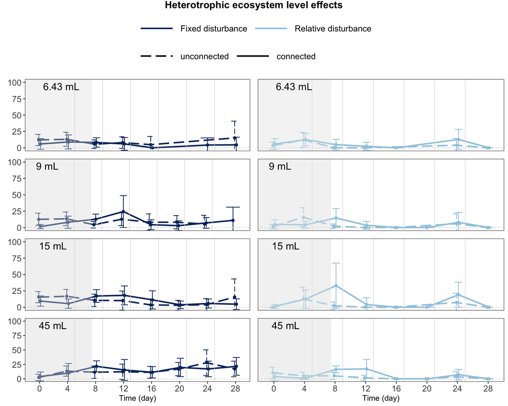

```r
plot.ecos.sizes.one.by.one.means(ds_ecosystems,
                                 "heterotrophic",
                                 response_variable_selected,
                                 light_colour_hetero,
                                 dark_colour_hetero,
                                 y_upper_limit_selected) +
  ggtitle("Heterotrophic ecosystem level effects") +
  theme(plot.title = element_text(size = plot_title_size,
                                  face = plot_title_face,
                                  hjust = plot_title_hjust))
```

**Prepare & plot data for analysis**

```r
# --- PREPARE DATA FOR ANALYSIS --- #

# Add baselines

baseline = ds_ecosystems %>%
  filter(time_point == time_point_of_baselines) %>%
  select(ecosystem_ID,
         all_of(response_variable_selected)) %>%
  rename(baseline = all_of(response_variable_selected))

data_for_analysis = ds_ecosystems %>%
  left_join(baseline)

# Filter and mutate

data_for_analysis = data_for_analysis %>%
  filter(time_point %in% time_points_model,
         !is.na(!!sym(response_variable_selected))) %>%
  mutate(trophic_type = as.factor(trophic_type),
         size = as.factor(ecosystem_size_ml),
         conn = factor(x = ifelse(connection == "connected",
                                  "con",
                                  "unconnected"),
                       levels = c("unconnected", "con")),
         volume_disturbed_across_sizes = as.factor(volume_disturbed_across_sizes),
         day = as.double(day),
         ecosystem_ID = as.factor(ecosystem_ID))
```

```r
# --- PLOT ONE PLOT PER ECOSYSTEM SIZE --- #

# Plot heterotrophic ecosystems

print("Heterotrophic ecosystems")
```

```
## [1] "Heterotrophic ecosystems"
```

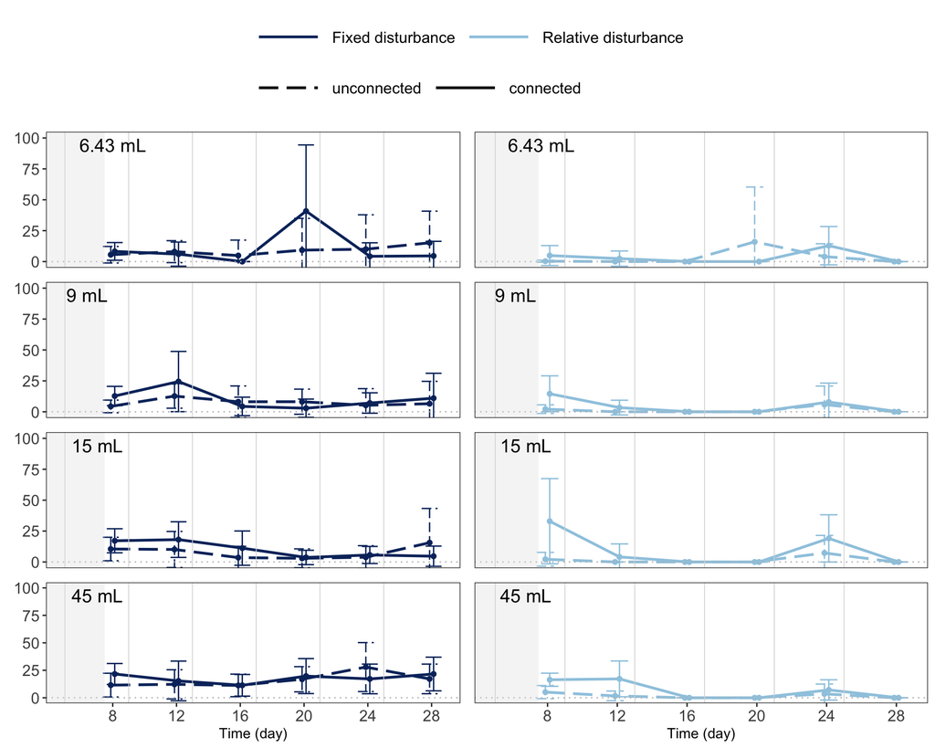

```r
plot.ecos.sizes.one.by.one.means(data_for_analysis,
                                 "heterotrophic",
                                 response_variable_selected,
                                 light_colour_hetero,
                                 dark_colour_hetero,
                                 y_upper_limit_selected)
```

#### Cep

```r
response_variable_selected = "Cep_bioarea_mm2_per_ml_dominance"
y_upper_limit_selected = 100
```

**Plot original data**

```r
# --- PLOT ONE PLOT PER ECOSYSTEM SIZE --- #

# Plot heterotrophic ecosystems

print("Heterotrophic ecosystems")
```

```
## [1] "Heterotrophic ecosystems"
```

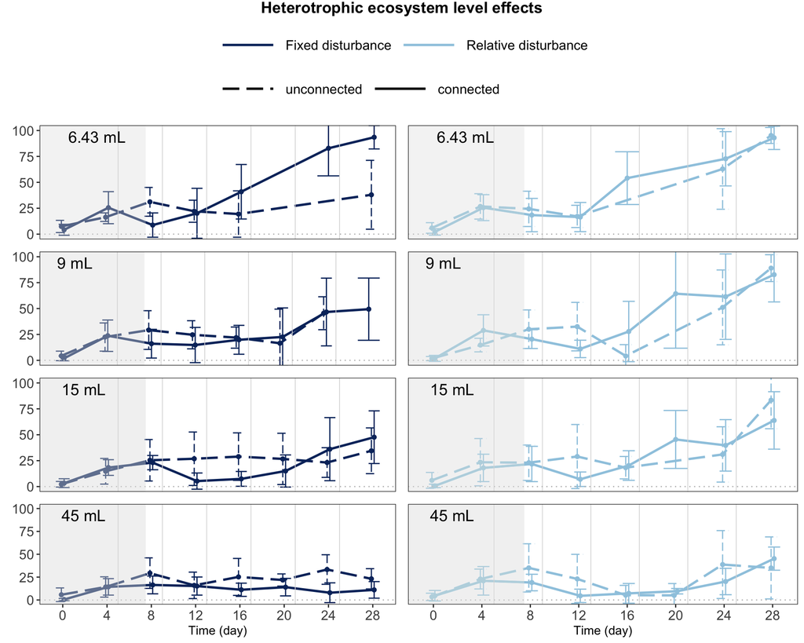

```r
plot.ecos.sizes.one.by.one.means(ds_ecosystems,
                                 "heterotrophic",
                                 response_variable_selected,
                                 light_colour_hetero,
                                 dark_colour_hetero,
                                 y_upper_limit_selected) +
  ggtitle("Heterotrophic ecosystem level effects") +
  theme(plot.title = element_text(size = plot_title_size,
                                  face = plot_title_face,
                                  hjust = plot_title_hjust))
```

**Prepare & plot data for analysis**

```r
# --- PREPARE DATA FOR ANALYSIS --- #

# Add baselines

baseline = ds_ecosystems %>%
  filter(time_point == time_point_of_baselines) %>%
  select(ecosystem_ID,
         all_of(response_variable_selected)) %>%
  rename(baseline = all_of(response_variable_selected))

data_for_analysis = ds_ecosystems %>%
  left_join(baseline)

# Filter and mutate

data_for_analysis = data_for_analysis %>%
  filter(time_point %in% time_points_model,
         !is.na(!!sym(response_variable_selected))) %>%
  mutate(trophic_type = as.factor(trophic_type),
         size = as.factor(ecosystem_size_ml),
         conn = factor(x = ifelse(connection == "connected",
                                  "con",
                                  "unconnected"),
                       levels = c("unconnected", "con")),
         volume_disturbed_across_sizes = as.factor(volume_disturbed_across_sizes),
         day = as.double(day),
         ecosystem_ID = as.factor(ecosystem_ID))
```

```r
# --- PLOT ONE PLOT PER ECOSYSTEM SIZE --- #

# Plot heterotrophic ecosystems

print("Heterotrophic ecosystems")
```

```
## [1] "Heterotrophic ecosystems"
```

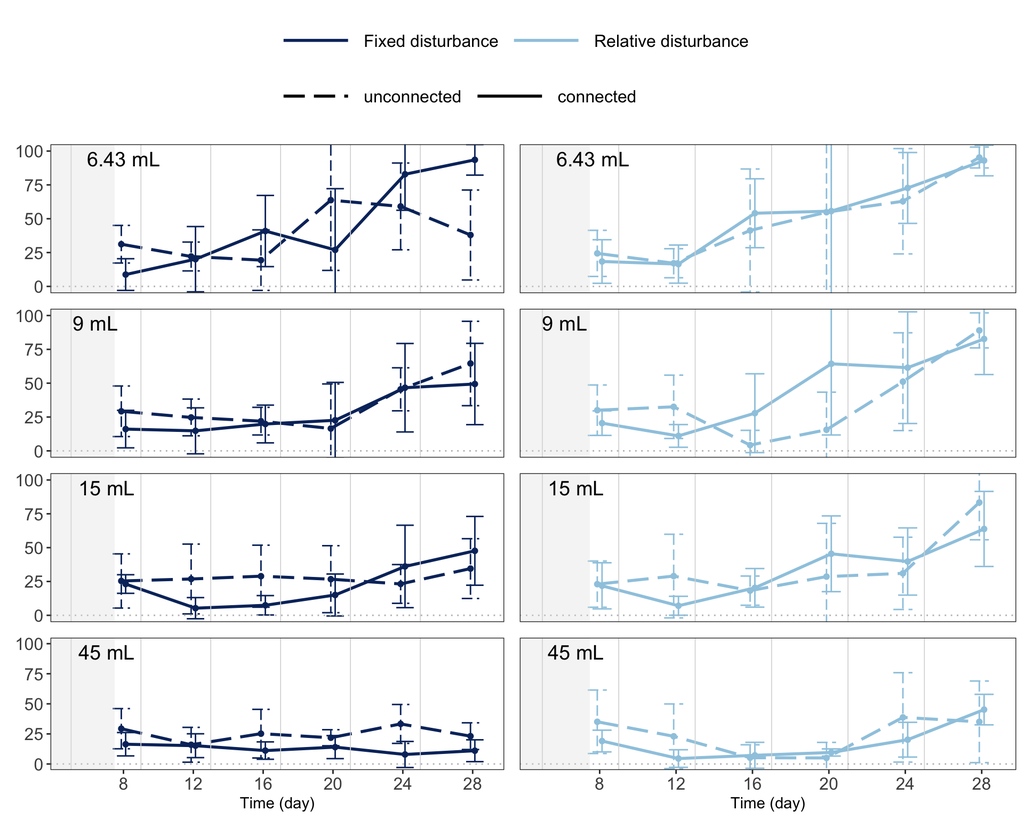

```r
plot.ecos.sizes.one.by.one.means(data_for_analysis,
                                 "heterotrophic",
                                 response_variable_selected,
                                 light_colour_hetero,
                                 dark_colour_hetero,
                                 y_upper_limit_selected)
```

#### Col

```r
response_variable_selected = "Col_bioarea_mm2_per_ml_dominance"
y_upper_limit_selected = 100
```

**Plot original data**

```r
# --- PLOT ONE PLOT PER ECOSYSTEM SIZE --- #

# Plot heterotrophic ecosystems

print("Heterotrophic ecosystems")
```

```
## [1] "Heterotrophic ecosystems"
```

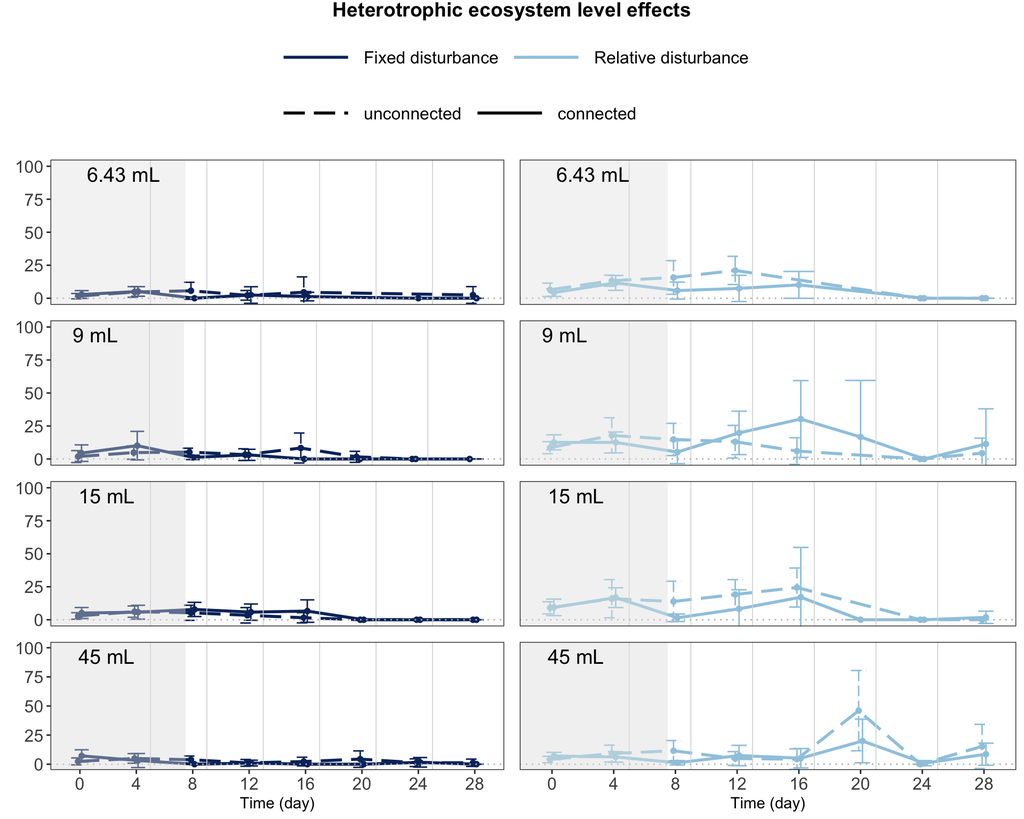

```r
plot.ecos.sizes.one.by.one.means(ds_ecosystems,
                                 "heterotrophic",
                                 response_variable_selected,
                                 light_colour_hetero,
                                 dark_colour_hetero,
                                 y_upper_limit_selected) +
  ggtitle("Heterotrophic ecosystem level effects") +
  theme(plot.title = element_text(size = plot_title_size,
                                  face = plot_title_face,
                                  hjust = plot_title_hjust))
```

**Prepare & plot data for analysis**

```r
# --- PREPARE DATA FOR ANALYSIS --- #

# Add baselines

baseline = ds_ecosystems %>%
  filter(time_point == time_point_of_baselines) %>%
  select(ecosystem_ID,
         all_of(response_variable_selected)) %>%
  rename(baseline = all_of(response_variable_selected))

data_for_analysis = ds_ecosystems %>%
  left_join(baseline)

# Filter and mutate

data_for_analysis = data_for_analysis %>%
  filter(time_point %in% time_points_model,
         !is.na(!!sym(response_variable_selected))) %>%
  mutate(trophic_type = as.factor(trophic_type),
         size = as.factor(ecosystem_size_ml),
         conn = factor(x = ifelse(connection == "connected",
                                  "con",
                                  "unconnected"),
                       levels = c("unconnected", "con")),
         volume_disturbed_across_sizes = as.factor(volume_disturbed_across_sizes),
         day = as.double(day),
         ecosystem_ID = as.factor(ecosystem_ID))
```

```r
# --- PLOT ONE PLOT PER ECOSYSTEM SIZE --- #

# Plot heterotrophic ecosystems

print("Heterotrophic ecosystems")
```

```
## [1] "Heterotrophic ecosystems"
```

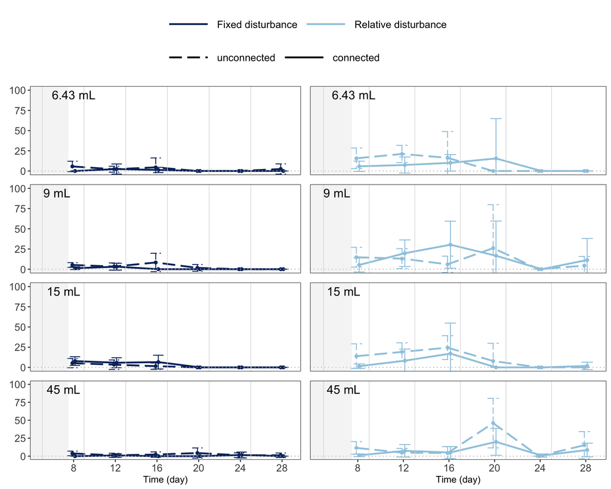

```r
plot.ecos.sizes.one.by.one.means(data_for_analysis,
                                 "heterotrophic",
                                 response_variable_selected,
                                 light_colour_hetero,
                                 dark_colour_hetero,
                                 y_upper_limit_selected)
```

#### Eup

```r
response_variable_selected = "Eup_bioarea_mm2_per_ml_dominance"
y_upper_limit_selected = 100
```

**Plot original data**

```r
# --- PLOT ONE PLOT PER ECOSYSTEM SIZE --- #

# Plot heterotrophic ecosystems

print("Heterotrophic ecosystems")
```

```
## [1] "Heterotrophic ecosystems"
```

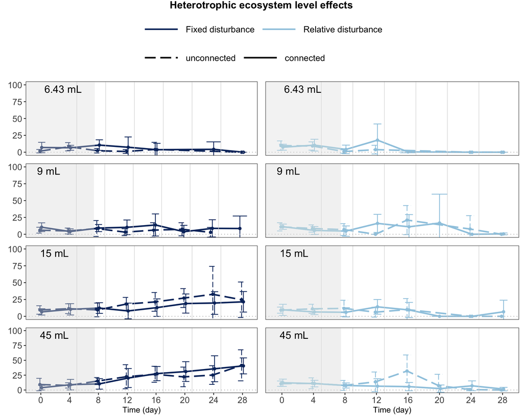

```r
plot.ecos.sizes.one.by.one.means(ds_ecosystems,
                                 "heterotrophic",
                                 response_variable_selected,
                                 light_colour_hetero,
                                 dark_colour_hetero,
                                 y_upper_limit_selected) +
  ggtitle("Heterotrophic ecosystem level effects") +
  theme(plot.title = element_text(size = plot_title_size,
                                  face = plot_title_face,
                                  hjust = plot_title_hjust))
```

**Prepare & plot data for analysis**

```r
# --- PREPARE DATA FOR ANALYSIS --- #

# Add baselines

baseline = ds_ecosystems %>%
  filter(time_point == time_point_of_baselines) %>%
  select(ecosystem_ID,
         all_of(response_variable_selected)) %>%
  rename(baseline = all_of(response_variable_selected))

data_for_analysis = ds_ecosystems %>%
  left_join(baseline)

# Filter and mutate

data_for_analysis = data_for_analysis %>%
  filter(time_point %in% time_points_model,
         !is.na(!!sym(response_variable_selected))) %>%
  mutate(trophic_type = as.factor(trophic_type),
         size = as.factor(ecosystem_size_ml),
         conn = factor(x = ifelse(connection == "connected",
                                  "con",
                                  "unconnected"),
                       levels = c("unconnected", "con")),
         volume_disturbed_across_sizes = as.factor(volume_disturbed_across_sizes),
         day = as.double(day),
         ecosystem_ID = as.factor(ecosystem_ID))
```

```r
# --- PLOT ONE PLOT PER ECOSYSTEM SIZE --- #

# Plot heterotrophic ecosystems

print("Heterotrophic ecosystems")
```

```
## [1] "Heterotrophic ecosystems"
```

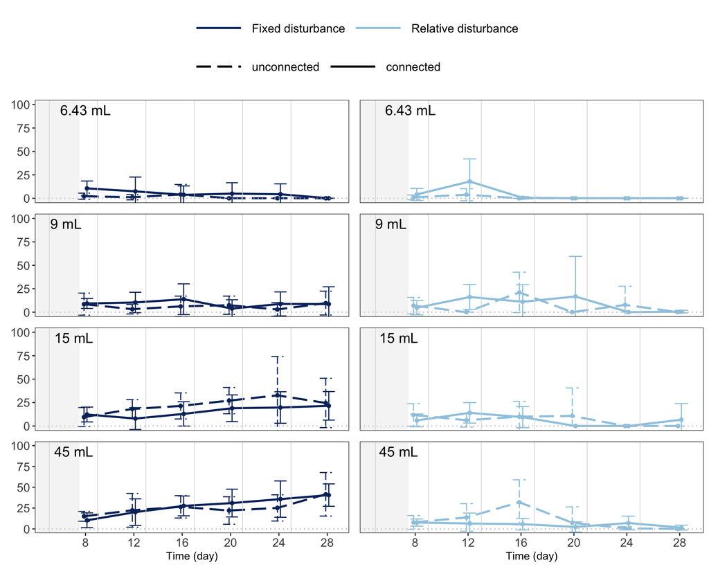

```r
plot.ecos.sizes.one.by.one.means(data_for_analysis,
                                 "heterotrophic",
                                 response_variable_selected,
                                 light_colour_hetero,
                                 dark_colour_hetero,
                                 y_upper_limit_selected)
```

#### Lox

```r
response_variable_selected = "Lox_bioarea_mm2_per_ml_dominance"
y_upper_limit_selected = 100
```

**Plot original data**

```r
# --- PLOT ONE PLOT PER ECOSYSTEM SIZE --- #

# Plot heterotrophic ecosystems

print("Heterotrophic ecosystems")
```

```
## [1] "Heterotrophic ecosystems"
```

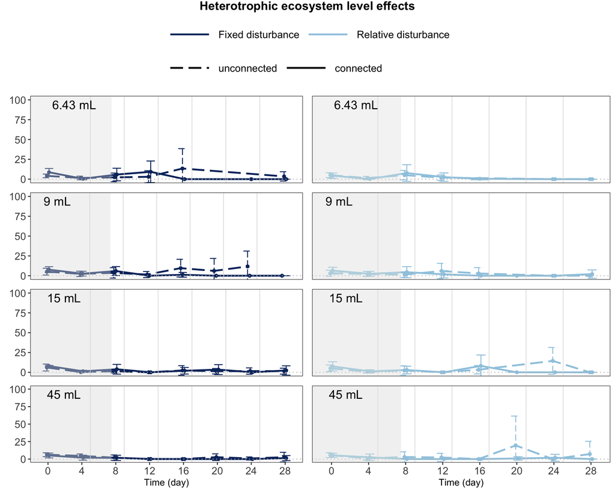

```r
plot.ecos.sizes.one.by.one.means(ds_ecosystems,
                                 "heterotrophic",
                                 response_variable_selected,
                                 light_colour_hetero,
                                 dark_colour_hetero,
                                 y_upper_limit_selected) +
  ggtitle("Heterotrophic ecosystem level effects") +
  theme(plot.title = element_text(size = plot_title_size,
                                  face = plot_title_face,
                                  hjust = plot_title_hjust))
```

**Prepare & plot data for analysis**

```r
# --- PREPARE DATA FOR ANALYSIS --- #

# Add baselines

baseline = ds_ecosystems %>%
  filter(time_point == time_point_of_baselines) %>%
  select(ecosystem_ID,
         all_of(response_variable_selected)) %>%
  rename(baseline = all_of(response_variable_selected))

data_for_analysis = ds_ecosystems %>%
  left_join(baseline)

# Filter and mutate

data_for_analysis = data_for_analysis %>%
  filter(time_point %in% time_points_model,
         !is.na(!!sym(response_variable_selected))) %>%
  mutate(trophic_type = as.factor(trophic_type),
         size = as.factor(ecosystem_size_ml),
         conn = factor(x = ifelse(connection == "connected",
                                  "con",
                                  "unconnected"),
                       levels = c("unconnected", "con")),
         volume_disturbed_across_sizes = as.factor(volume_disturbed_across_sizes),
         day = as.double(day),
         ecosystem_ID = as.factor(ecosystem_ID))
```

```r
# --- PLOT ONE PLOT PER ECOSYSTEM SIZE --- #

# Plot heterotrophic ecosystems

print("Heterotrophic ecosystems")
```

```
## [1] "Heterotrophic ecosystems"
```

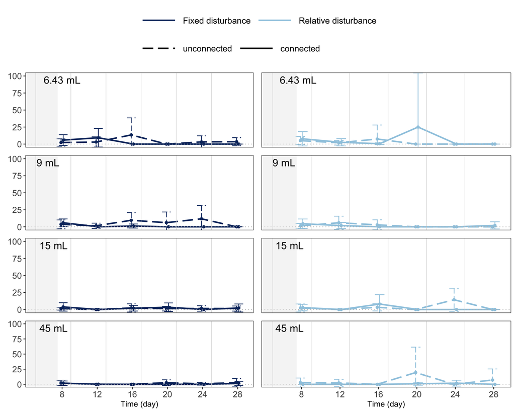

```r
plot.ecos.sizes.one.by.one.means(data_for_analysis,
                                 "heterotrophic",
                                 response_variable_selected,
                                 light_colour_hetero,
                                 dark_colour_hetero,
                                 y_upper_limit_selected)
```

#### Pau

```r
response_variable_selected = "Pau_bioarea_mm2_per_ml_dominance"
y_upper_limit_selected = 100
```

**Plot original data**

```r
# --- PLOT ONE PLOT PER ECOSYSTEM SIZE --- #

# Plot heterotrophic ecosystems

print("Heterotrophic ecosystems")
```

```
## [1] "Heterotrophic ecosystems"
```

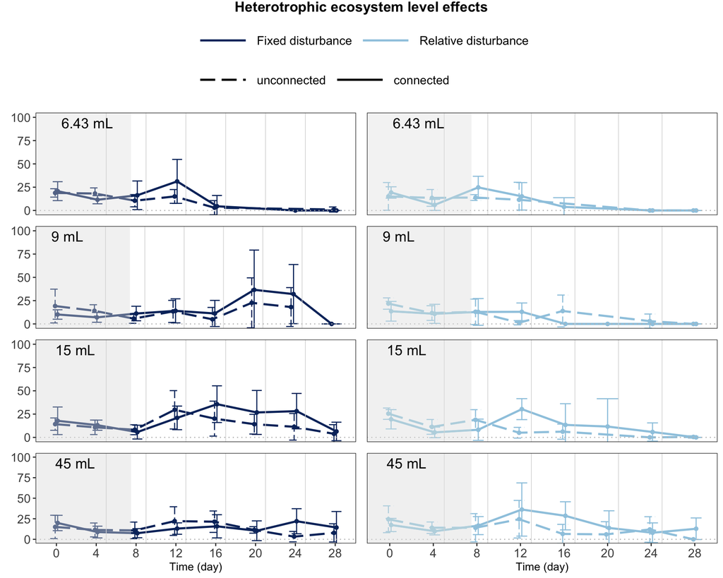

```r
plot.ecos.sizes.one.by.one.means(ds_ecosystems,
                                 "heterotrophic",
                                 response_variable_selected,
                                 light_colour_hetero,
                                 dark_colour_hetero,
                                 y_upper_limit_selected) +
  ggtitle("Heterotrophic ecosystem level effects") +
  theme(plot.title = element_text(size = plot_title_size,
                                  face = plot_title_face,
                                  hjust = plot_title_hjust))
```

**Prepare & plot data for analysis**

```r
# --- PREPARE DATA FOR ANALYSIS --- #

# Add baselines

baseline = ds_ecosystems %>%
  filter(time_point == time_point_of_baselines) %>%
  select(ecosystem_ID,
         all_of(response_variable_selected)) %>%
  rename(baseline = all_of(response_variable_selected))

data_for_analysis = ds_ecosystems %>%
  left_join(baseline)

# Filter and mutate

data_for_analysis = data_for_analysis %>%
  filter(time_point %in% time_points_model,
         !is.na(!!sym(response_variable_selected))) %>%
  mutate(trophic_type = as.factor(trophic_type),
         size = as.factor(ecosystem_size_ml),
         conn = factor(x = ifelse(connection == "connected",
                                  "con",
                                  "unconnected"),
                       levels = c("unconnected", "con")),
         volume_disturbed_across_sizes = as.factor(volume_disturbed_across_sizes),
         day = as.double(day),
         ecosystem_ID = as.factor(ecosystem_ID))
```

```r
# --- PLOT ONE PLOT PER ECOSYSTEM SIZE --- #

# Plot heterotrophic ecosystems

print("Heterotrophic ecosystems")
```

```
## [1] "Heterotrophic ecosystems"
```

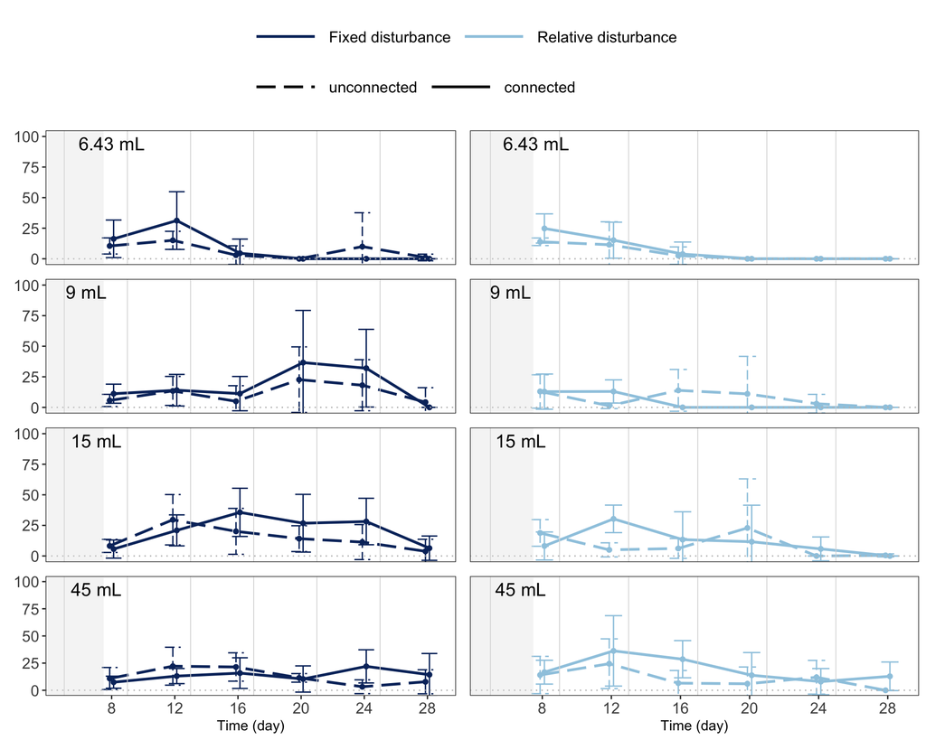

```r
plot.ecos.sizes.one.by.one.means(data_for_analysis,
                                 "heterotrophic",
                                 response_variable_selected,
                                 light_colour_hetero,
                                 dark_colour_hetero,
                                 y_upper_limit_selected)
```

#### Pca

```r
response_variable_selected = "Pca_bioarea_mm2_per_ml_dominance"
y_upper_limit_selected = 100
```

**Plot original data**

```r
# --- PLOT ONE PLOT PER ECOSYSTEM SIZE --- #

# Plot heterotrophic ecosystems

print("Heterotrophic ecosystems")
```

```
## [1] "Heterotrophic ecosystems"
```

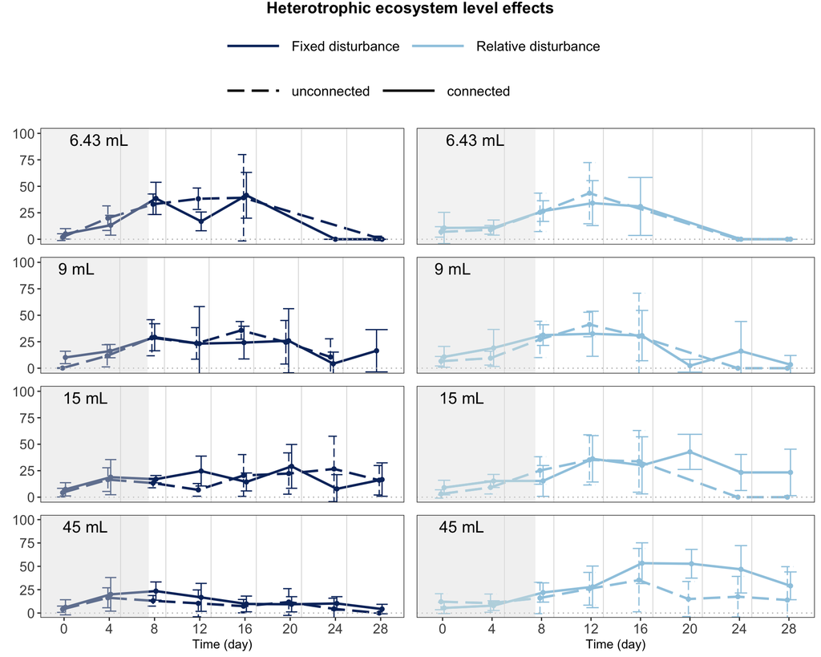

```r
plot.ecos.sizes.one.by.one.means(ds_ecosystems,
                                 "heterotrophic",
                                 response_variable_selected,
                                 light_colour_hetero,
                                 dark_colour_hetero,
                                 y_upper_limit_selected) +
  ggtitle("Heterotrophic ecosystem level effects") +
  theme(plot.title = element_text(size = plot_title_size,
                                  face = plot_title_face,
                                  hjust = plot_title_hjust))
```

**Prepare & plot data for analysis**

```r
# --- PREPARE DATA FOR ANALYSIS --- #

# Add baselines

baseline = ds_ecosystems %>%
  filter(time_point == time_point_of_baselines) %>%
  select(ecosystem_ID,
         all_of(response_variable_selected)) %>%
  rename(baseline = all_of(response_variable_selected))

data_for_analysis = ds_ecosystems %>%
  left_join(baseline)

# Filter and mutate

data_for_analysis = data_for_analysis %>%
  filter(time_point %in% time_points_model,
         !is.na(!!sym(response_variable_selected))) %>%
  mutate(trophic_type = as.factor(trophic_type),
         size = as.factor(ecosystem_size_ml),
         conn = factor(x = ifelse(connection == "connected",
                                  "con",
                                  "unconnected"),
                       levels = c("unconnected", "con")),
         volume_disturbed_across_sizes = as.factor(volume_disturbed_across_sizes),
         day = as.double(day),
         ecosystem_ID = as.factor(ecosystem_ID))
```

```r
# --- PLOT ONE PLOT PER ECOSYSTEM SIZE --- #

# Plot heterotrophic ecosystems

print("Heterotrophic ecosystems")
```

```
## [1] "Heterotrophic ecosystems"
```

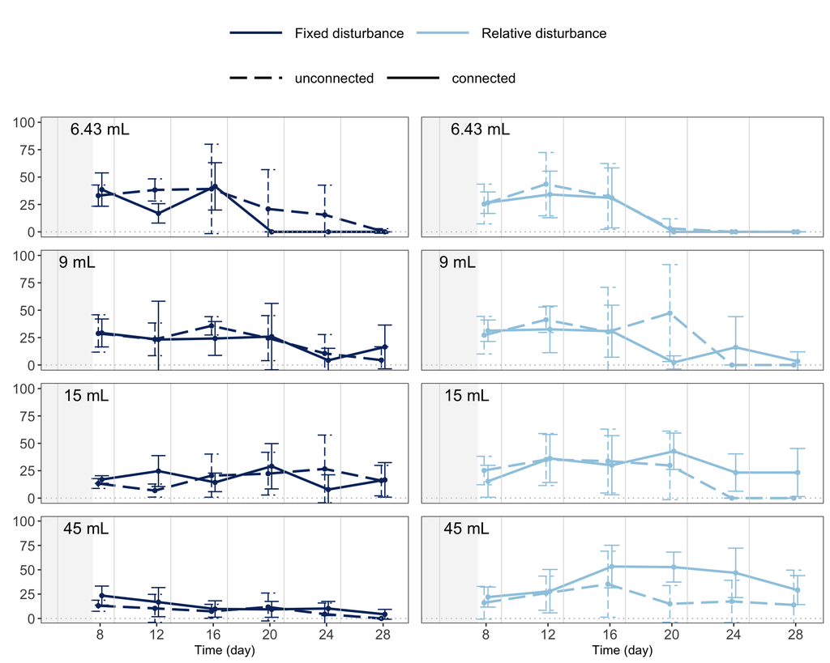

```r
plot.ecos.sizes.one.by.one.means(data_for_analysis,
                                 "heterotrophic",
                                 response_variable_selected,
                                 light_colour_hetero,
                                 dark_colour_hetero,
                                 y_upper_limit_selected)
```

#### Spi

```r
response_variable_selected = "Spi_bioarea_mm2_per_ml_dominance"
y_upper_limit_selected = 100
```

**Plot original data**

```r
# --- PLOT ONE PLOT PER ECOSYSTEM SIZE --- #

# Plot heterotrophic ecosystems

print("Heterotrophic ecosystems")
```

```
## [1] "Heterotrophic ecosystems"
```

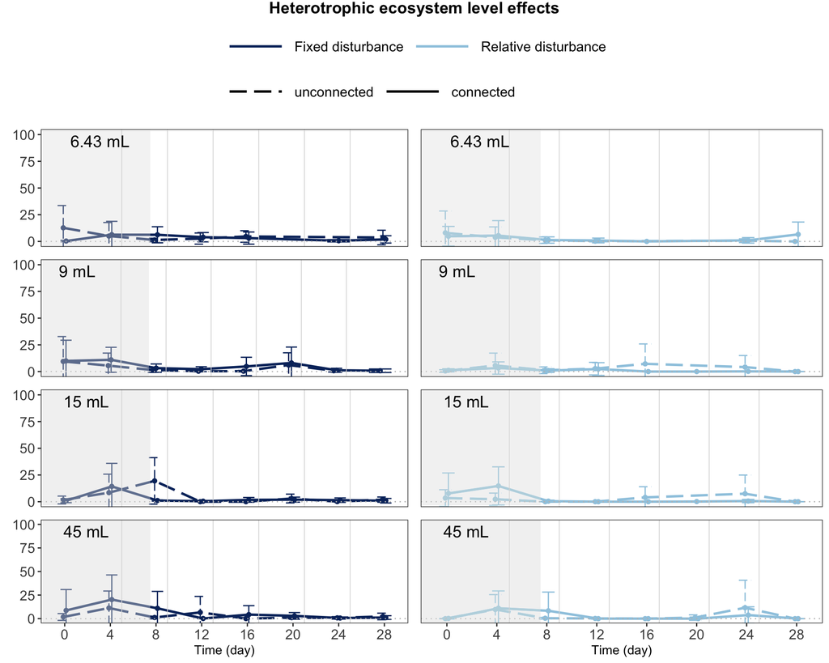

```r
plot.ecos.sizes.one.by.one.means(ds_ecosystems,
                                 "heterotrophic",
                                 response_variable_selected,
                                 light_colour_hetero,
                                 dark_colour_hetero,
                                 y_upper_limit_selected) +
  ggtitle("Heterotrophic ecosystem level effects") +
  theme(plot.title = element_text(size = plot_title_size,
                                  face = plot_title_face,
                                  hjust = plot_title_hjust))
```

**Prepare & plot data for analysis**

```r
# --- PREPARE DATA FOR ANALYSIS --- #

# Add baselines

baseline = ds_ecosystems %>%
  filter(time_point == time_point_of_baselines) %>%
  select(ecosystem_ID,
         all_of(response_variable_selected)) %>%
  rename(baseline = all_of(response_variable_selected))

data_for_analysis = ds_ecosystems %>%
  left_join(baseline)

# Filter and mutate

data_for_analysis = data_for_analysis %>%
  filter(time_point %in% time_points_model,
         !is.na(!!sym(response_variable_selected))) %>%
  mutate(trophic_type = as.factor(trophic_type),
         size = as.factor(ecosystem_size_ml),
         conn = factor(x = ifelse(connection == "connected",
                                  "con",
                                  "unconnected"),
                       levels = c("unconnected", "con")),
         volume_disturbed_across_sizes = as.factor(volume_disturbed_across_sizes),
         day = as.double(day),
         ecosystem_ID = as.factor(ecosystem_ID))
```

```r
# --- PLOT ONE PLOT PER ECOSYSTEM SIZE --- #

# Plot heterotrophic ecosystems

print("Heterotrophic ecosystems")
```

```
## [1] "Heterotrophic ecosystems"
```

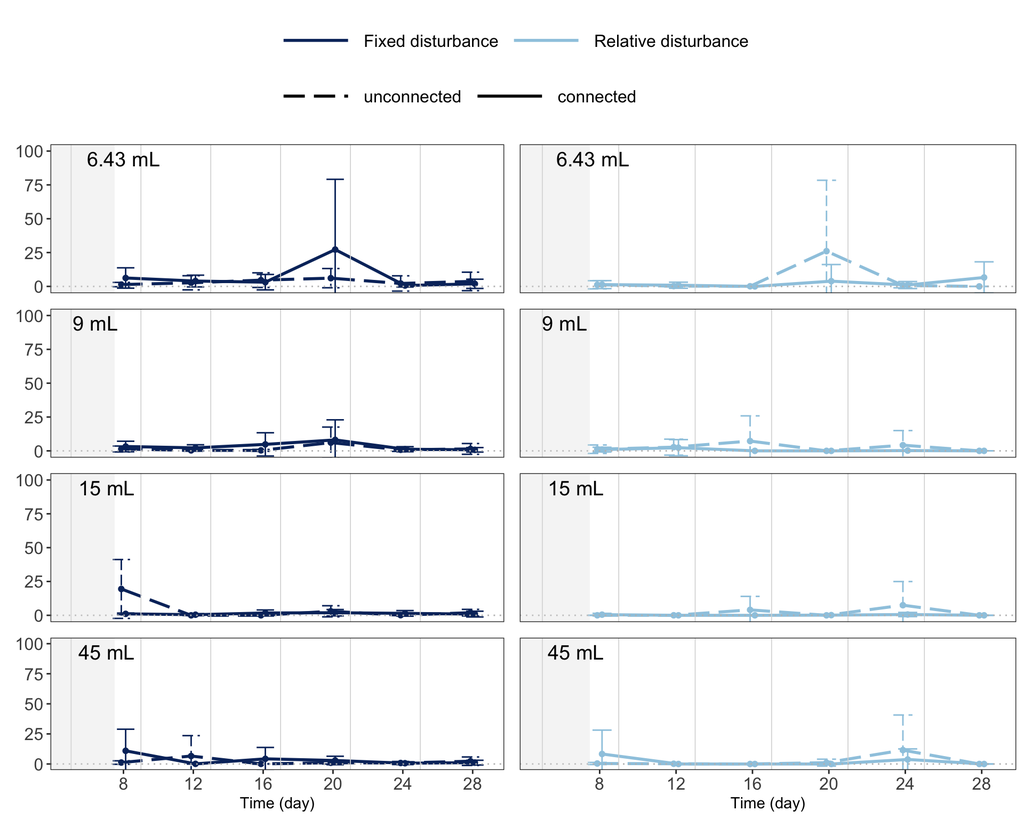

```r
plot.ecos.sizes.one.by.one.means(data_for_analysis,
                                 "heterotrophic",
                                 response_variable_selected,
                                 light_colour_hetero,
                                 dark_colour_hetero,
                                 y_upper_limit_selected)
```